# Do Protests Really Spread?

Self-Excitation in Indonesian Protests

Daniel Carnahan

January 2026

# 1 Overview

This document provides a complete, reproducible pipeline for analyzing protest diffusion in Indonesia using a discrete spatial Hawkes process. The analysis addresses two main questions:

1. **Do protests elsewhere predict more protests here?** (Cross-district contagion)
2. **Does geography matter—is spread local or national?** (Spatial decay)

## 1.2 Data Sources

| Data | Source | File |
| --- | --- | --- |
| Protest events | ACLED | `ACLED Data_2025-10-27_Indonesia20142024_OFFICIAL.xlsx` |
| Population | World Bank DAPOER | `district_level_population_2014_2020.csv` |
| Poverty rates | World Bank DAPOER | `district_level_population_2014_2020.csv` |
| CPI | FRED | `indonesia_cpi_fred.csv` |
| Shapefiles | GADM 4.1 | `Indonesian district-level shapefile copy 2/` |

# 2 Setup

## 2.1 Load Required Packages

```r
# Core packages
library(tidyverse)
library(sf)
library(readxl)
library(lubridate)
library(MASS)
library(geosphere)
library(scales)
library(spdep)      # Spatial autocorrelation diagnostics
library(sandwich)   # Robust/clustered standard errors
library(lmtest)     # Coefficient testing with robust SEs
library(mgcv)       # Generalized additive models (for random effects and splines)
library(zoo)        # Rolling window functions
library(numDeriv)   # Numerical derivatives for Hessian in custom likelihoods

# Fix MASS masking dplyr::select
select <- dplyr::select

# Presentation theme for figures
theme_presentation <- theme_minimal(base_size = 14) +
  theme(
    panel.grid.minor = element_blank(),
    panel.grid.major.x = element_blank(),
    plot.title = element_text(face = "bold", size = 16),
    axis.title = element_text(size = 14),
    axis.text = element_text(size = 12),
    legend.position = "bottom"
  )
```

# 3 Data Preparation

## 3.1 Step 1: Prepare Protest Data

Load raw ACLED data and perform initial processing:

- Filter to protest and riot events
- Classify events by violence level
- Extract temporal components
- Create spatial features

```r
cat("=== STEP 1: PREPARING PROTEST DATA ===\n\n")
```

```
## === STEP 1: PREPARING PROTEST DATA ===
```

```r
# Load ACLED data
acled_raw <- read_excel("ACLED Data_2025-10-27_Indonesia20142024_OFFICIAL.xlsx")

# Extract column names from first row
col_names <- as.character(acled_raw[1, ])
acled <- acled_raw[-1, ]
names(acled) <- col_names

# Convert columns to appropriate types
acled <- acled %>%
  mutate(
    event_date = if (is.numeric(event_date)) {
      as.Date(event_date, origin = "1899-12-30")
    } else {
      lubridate::ymd(event_date)
    },
    year = as.integer(year),
    latitude = as.numeric(latitude),
    longitude = as.numeric(longitude),
    fatalities = as.integer(fatalities),
    time_precision = as.integer(time_precision)
  )

cat("Total events:", nrow(acled), "\n\n")
```

```
## Total events: 18573
```

```r
# Filter to protest events
protests <- acled %>%
  filter(event_type %in% c("Protests", "Riots"))

cat("Protest events:", nrow(protests), "\n")
```

```
## Protest events: 16467
```

```r
cat("  - Protests:", sum(protests$event_type == "Protests"), "\n")
```

```
##   - Protests: 15003
```

```r
cat("  - Riots:", sum(protests$event_type == "Riots"), "\n\n")
```

```
##   - Riots: 1464
```

```r
# Create sub-categories for analysis
protests <- protests %>%
  mutate(
    # Classify by violence level
    is_violent = sub_event_type %in% c("Violent demonstration",
                                        "Protest with intervention",
                                        "Mob violence",
                                        "Looting/property destruction",
                                        "Excessive force against protesters"),
    is_peaceful = sub_event_type == "Peaceful protest",
    has_fatalities = fatalities > 0,

    # Extract temporal components
    month = month(event_date),
    day_of_year = yday(event_date),
    week = week(event_date),
    days_since_start = as.numeric(event_date - min(event_date)),
    year_month = floor_date(event_date, "month")
  ) %>%
  arrange(event_date)

cat("Violence classification:\n")
```

```
## Violence classification:
```

```r
cat("  - Peaceful:", sum(protests$is_peaceful), "\n")
```

```
##   - Peaceful: 14235
```

```r
cat("  - Violent:", sum(protests$is_violent), "\n")
```

```
##   - Violent: 2232
```

```r
cat("  - With fatalities:", sum(protests$has_fatalities), "\n\n")
```

```
##   - With fatalities: 152
```

```r
cat("Temporal range:", as.character(min(protests$event_date)), "to",
    as.character(max(protests$event_date)), "\n")
```

```
## Temporal range: 2015-01-01 to 2024-10-27
```

```r
cat("Total observation period:", max(protests$days_since_start), "days\n")
```

```
## Total observation period: 3587 days
```

## 3.2 Step 2: Prepare Population Data

Spatially match protests to district boundaries and join population data.

```r
cat("\n=== STEP 2: PREPARING POPULATION DATA ===\n\n")
```

```
##
## === STEP 2: PREPARING POPULATION DATA ===
```

```r
# Load population data
pop_raw <- read.csv("district_level_population_2014_2020.csv",
                    stringsAsFactors = FALSE)

cat("Loaded", nrow(pop_raw), "rows from population CSV\n")
```

```
## Loaded 2575 rows from population CSV
```

```r
# Filter for total population series
pop_data <- pop_raw %>%
  filter(Series.Name == "Total Population (in number of people)") %>%
  select(district = Provinces.Name,
         `2014` = X2014..YR2014.,
         `2015` = X2015..YR2015.,
         `2016` = X2016..YR2016.,
         `2017` = X2017..YR2017.,
         `2018` = X2018..YR2018.,
         `2019` = X2019..YR2019.,
         `2020` = X2020..YR2020.)

# Remove leading quote if present
pop_data$district <- gsub('^"', '', pop_data$district)

cat("Loaded", nrow(pop_data), "districts with population data\n\n")
```

```
## Loaded 514 districts with population data
```

```r
# Load GADM shapefile for spatial matching
gadm <- st_read("Indonesian district-level shapefile copy 2/gadm41_IDN_2.shp", quiet = TRUE)

cat("Loaded GADM shapefile:", nrow(gadm), "features\n")
```

```
## Loaded GADM shapefile: 502 features
```

```r
cat("  Kota (cities):", sum(gadm$ENGTYPE_2 == "City"), "\n")
```

```
##   Kota (cities): 97
```

```r
cat("  Kabupaten (regencies):", sum(gadm$ENGTYPE_2 == "Regency"), "\n\n")
```

```
##   Kabupaten (regencies): 396
```

```r
# Compute district centroids from GADM polygons
# Use st_point_on_surface() to guarantee point inside polygon (handles irregular shapes)
gadm_centroids <- gadm %>%
  mutate(
    centroid = st_point_on_surface(geometry),
    lon = st_coordinates(centroid)[, 1],
    lat = st_coordinates(centroid)[, 2]
  ) %>%
  st_drop_geometry() %>%
  select(admin2 = NAME_2, lon, lat)

cat("Computed centroids for", nrow(gadm_centroids), "districts\n\n")
```

```
## Computed centroids for 502 districts
```

```r
# Convert protests to sf points for spatial join
protests_with_coords <- protests %>%
  filter(!is.na(latitude) & !is.na(longitude))

protests_sf <- st_as_sf(protests_with_coords,
                        coords = c("longitude", "latitude"),
                        crs = 4326)

cat("Performing spatial join for", nrow(protests_sf), "protests...\n")
```

```
## Performing spatial join for 16467 protests...
```

```r
# Spatial join: protests → GADM polygons
protests_matched <- st_join(protests_sf, gadm, join = st_intersects)

# Convert GADM names to population CSV format
gadm_to_pop_name <- function(name_2, engtype_2) {
  if (is.na(engtype_2) || is.na(name_2)) return(NA_character_)
  if (engtype_2 == "City") {
    base_name <- sub("^Kota\\s+", "", name_2)
    return(paste0(base_name, ", Kota"))
  } else {
    return(paste0(name_2, ", Kab."))
  }
}

protests_matched$district <- mapply(gadm_to_pop_name,
                                    protests_matched$NAME_2,
                                    protests_matched$ENGTYPE_2)

# Convert back to regular dataframe
protests_matched_df <- protests_matched %>%
  st_drop_geometry() %>%
  select(event_id_cnty, NAME_2, ENGTYPE_2, district)

cat("Spatial matching complete:\n")
```

```
## Spatial matching complete:
```

```r
cat("  Matched:", sum(!is.na(protests_matched_df$district)),
    "(", round(100*mean(!is.na(protests_matched_df$district)), 1), "%)\n\n")
```

```
##   Matched: 16445 ( 99.9 %)
```

```r
# Warn if district match rate is low - indicates naming convention issues
match_rate <- mean(!is.na(protests_matched_df$district))
if (match_rate < 0.95) {
  warning(sprintf("Only %.1f%% district match rate - verify GADM→DAPOER naming conventions", 100*match_rate))
}

# Sanity check: verify district naming conventions match between sources
cat("District naming sanity check:\n")
```

```
## District naming sanity check:
```

```r
cat("  Example districts from DAPOER CSV:\n")
```

```
##   Example districts from DAPOER CSV:
```

```r
print(head(pop_data$district, 10))
```

```
##  [1] "Badung, Kab."     "Bangli, Kab."     "Buleleng, Kab."   "Denpasar, Kota"
##  [5] "Gianyar, Kab."    "Jembrana, Kab."   "Karangasem, Kab." "Klungkung, Kab."
##  [9] "Tabanan, Kab."    "Cilegon, Kota"
```

```r
cat("\n  Example districts from GADM→DAPOER mapping:\n")
```

```
##
##   Example districts from GADM→DAPOER mapping:
```

```r
print(head(na.omit(protests_matched_df$district), 10))
```

```
##                   Sabang          Jakarta Selatan                 Surabaya
##           "Sabang, Kota"  "Jakarta Selatan, Kota"         "Surabaya, Kota"
##          Jakarta Selatan            Jakarta Pusat                   Mimika
##  "Jakarta Selatan, Kota"    "Jakarta Pusat, Kota"           "Mimika, Kab."
##         Mandailing Natal          Jakarta Selatan            Jakarta Pusat
## "Mandailing Natal, Kab."  "Jakarta Selatan, Kota"    "Jakarta Pusat, Kota"
##             Kota Cirebon
##          "Cirebon, Kota"
```

```r
cat("\n")
```

```r
# Reshape population to long format
pop_long <- pop_data %>%
  pivot_longer(cols = starts_with("20"),
               names_to = "year",
               values_to = "population") %>%
  mutate(year = as.integer(year),
         population = as.numeric(population)) %>%
  filter(!is.na(population))

# Extrapolate population to 2021-2024 using linear trends
districts_to_extrapolate <- unique(pop_long$district)

extrapolated_pop <- lapply(districts_to_extrapolate, function(dist) {
  hist_data <- pop_long %>% filter(district == dist)

  if (nrow(hist_data) >= 3) {
    model <- lm(population ~ year, data = hist_data)
    future_years <- data.frame(year = 2021:2024)
    predictions <- predict(model, newdata = future_years)

    future_data <- data.frame(
      district = dist,
      year = 2021:2024,
      population = pmax(predictions, min(hist_data$population)),
      extrapolated = TRUE
    )

    hist_data$extrapolated <- FALSE
    return(rbind(hist_data, future_data))
  } else {
    hist_data$extrapolated <- FALSE
    return(hist_data)
  }
})

pop_complete <- do.call(rbind, extrapolated_pop)
pop_complete$log_pop <- log(pmax(pop_complete$population, 1))

cat("Population data: ", nrow(pop_complete), "district-years (2014-2024)\n")
```

```
## Population data:  5627 district-years (2014-2024)
```

```r
cat("  Historical:", sum(!pop_complete$extrapolated), "\n")
```

```
##   Historical: 3583
```

```r
cat("  Extrapolated:", sum(pop_complete$extrapolated), "\n\n")
```

```
##   Extrapolated: 2044
```

```r
# Join spatial matching to original protests
protests_with_district <- protests %>%
  left_join(protests_matched_df %>% select(event_id_cnty, district),
            by = "event_id_cnty")

# Join to population data
protests_with_pop <- protests_with_district %>%
  left_join(pop_complete, by = c("district", "year"))

n_matched <- sum(!is.na(protests_with_pop$population))
cat("Population join results:\n")
```

```
## Population join results:
```

```r
cat("  Total protests:", nrow(protests_with_pop), "\n")
```

```
##   Total protests: 16467
```

```r
cat("  Matched to population:", n_matched,
    "(", round(100*n_matched/nrow(protests_with_pop), 1), "%)\n")
```

```
##   Matched to population: 15914 ( 96.6 %)
```

## 3.3 Step 3: Prepare Poverty Data

Extract poverty rate and extrapolate to 2021-2024.

```r
cat("\n=== STEP 3: PREPARING POVERTY DATA ===\n\n")
```

```
##
## === STEP 3: PREPARING POVERTY DATA ===
```

```r
# Extract poverty rate from population CSV
poverty_data <- pop_raw %>%
  filter(Series.Name == "Poverty Rate (in % of population)") %>%
  select(district = Provinces.Name,
         `2014` = X2014..YR2014.,
         `2015` = X2015..YR2015.,
         `2016` = X2016..YR2016.,
         `2017` = X2017..YR2017.,
         `2018` = X2018..YR2018.,
         `2019` = X2019..YR2019.,
         `2020` = X2020..YR2020.)

poverty_data$district <- gsub('^"', '', poverty_data$district)

# Reshape to long format
poverty_long <- poverty_data %>%
  pivot_longer(cols = `2014`:`2020`,
               names_to = "year",
               values_to = "poverty_rate") %>%
  mutate(year = as.integer(year),
         poverty_rate = as.numeric(poverty_rate))

# Filter to valid data for 2015-2020
poverty_clean <- poverty_long %>%
  filter(year >= 2015 & year <= 2020) %>%
  filter(!is.na(poverty_rate))

cat("Valid poverty data:", nrow(poverty_clean), "district-years (2015-2020)\n")
```

```
## Valid poverty data: 3080 district-years (2015-2020)
```

```r
cat("Unique districts:", n_distinct(poverty_clean$district), "\n\n")
```

```
## Unique districts: 514
```

```r
# Extrapolate 2021-2024 using linear trends from 2018-2020
poverty_trends <- poverty_clean %>%
  filter(year >= 2018 & year <= 2020) %>%
  group_by(district) %>%
  summarise(
    n_obs = n(),
    poverty_2018 = poverty_rate[year == 2018][1],
    poverty_2019 = poverty_rate[year == 2019][1],
    poverty_2020 = poverty_rate[year == 2020][1],
    annual_change = case_when(
      n_obs >= 3 ~ (poverty_2020 - poverty_2018) / 2,
      n_obs == 2 ~ poverty_2020 - poverty_2019,
      TRUE ~ 0
    ),
    .groups = "drop"
  )

# Project forward with bounds [0, 100]
poverty_projected <- poverty_trends %>%
  mutate(
    poverty_2021 = pmax(0, pmin(100, poverty_2020 + annual_change)),
    poverty_2022 = pmax(0, pmin(100, poverty_2020 + 2 * annual_change)),
    poverty_2023 = pmax(0, pmin(100, poverty_2020 + 3 * annual_change)),
    poverty_2024 = pmax(0, pmin(100, poverty_2020 + 4 * annual_change))
  ) %>%
  select(district, poverty_2021, poverty_2022, poverty_2023, poverty_2024)

# Convert to long format
poverty_future <- poverty_projected %>%
  pivot_longer(cols = starts_with("poverty_"),
               names_to = "year",
               names_prefix = "poverty_",
               values_to = "poverty_rate") %>%
  mutate(year = as.integer(year),
         extrapolated = TRUE)

poverty_clean <- poverty_clean %>%
  mutate(extrapolated = FALSE)

# Combine historical and projected
poverty_full <- bind_rows(poverty_clean, poverty_future) %>%
  arrange(district, year)

cat("Total poverty data:", nrow(poverty_full), "district-years (2015-2024)\n")
```

```
## Total poverty data: 5136 district-years (2015-2024)
```

```r
cat("  Historical:", sum(!poverty_full$extrapolated), "\n")
```

```
##   Historical: 3080
```

```r
cat("  Extrapolated:", sum(poverty_full$extrapolated), "\n\n")
```

```
##   Extrapolated: 2056
```

```r
# Join poverty to protests
protests_with_poverty <- protests_with_pop %>%
  left_join(poverty_full %>% select(district, year, poverty_rate),
            by = c("district", "year")) %>%
  mutate(poverty_decimal = poverty_rate / 100)

n_pov_matched <- sum(!is.na(protests_with_poverty$poverty_rate))
cat("Poverty join results:\n")
```

```
## Poverty join results:
```

```r
cat("  Matched to poverty data:", n_pov_matched,
    "(", round(100*n_pov_matched/nrow(protests_with_poverty), 1), "%)\n")
```

```
##   Matched to poverty data: 15914 ( 96.6 %)
```

## 3.4 Step 4: Prepare CPI Data

Load and process Consumer Price Index data from FRED.

```r
cat("\n=== STEP 4: PREPARING CPI DATA ===\n\n")
```

```
##
## === STEP 4: PREPARING CPI DATA ===
```

```r
# Load raw CPI data from FRED
cpi_raw <- read_csv("indonesia_cpi_fred.csv", show_col_types = FALSE)

# Process CPI data
cpi <- cpi_raw %>%
  rename(date = observation_date, cpi = IDNCPIALLMINMEI) %>%
  mutate(
    date = as.Date(date),
    year = year(date),
    month = month(date),
    year_month = format(date, "%Y-%m"),
    log_cpi = log(cpi),
    inflation_mom = 100 * (cpi / lag(cpi) - 1),
    inflation_yoy = 100 * (cpi / lag(cpi, 12) - 1)
  ) %>%
  filter(year >= 2015 & year <= 2024)

cat("CPI data summary:\n")
```

```
## CPI data summary:
```

```r
cat("  Date range:", as.character(min(cpi$date)), "to", as.character(max(cpi$date)), "\n")
```

```
##   Date range: 2015-01-01 to 2024-12-01
```

```r
cat("  Number of months:", nrow(cpi), "\n\n")
```

```
##   Number of months: 120
```

```r
cat("CPI values:\n")
```

```
## CPI values:
```

```r
cat("  2015 Jan:", round(cpi$cpi[cpi$year_month == "2015-01"], 2), "\n")
```

```
##   2015 Jan: 98.58
```

```r
cat("  2020 Jan:", round(cpi$cpi[cpi$year_month == "2020-01"], 2), "\n")
```

```
##   2020 Jan: 115.82
```

```r
cat("  Latest:", round(tail(cpi$cpi, 1), 2), "\n\n")
```

```
##   Latest: 131.43
```

```r
cat("Year-over-year inflation range:\n")
```

```
## Year-over-year inflation range:
```

```r
cat("  Min:", round(min(cpi$inflation_yoy, na.rm = TRUE), 2), "%\n")
```

```
##   Min: 1.07 %
```

```r
cat("  Max:", round(max(cpi$inflation_yoy, na.rm = TRUE), 2), "%\n")
```

```
##   Max: 7.26 %
```

```r
cat("  Mean:", round(mean(cpi$inflation_yoy, na.rm = TRUE), 2), "%\n")
```

```
##   Mean: 3.35 %
```

## 3.5 Step 5: Collapse Multi-Day Protests

Collapse protests within 7 days at the same location into single events.

```r
cat("\n=== STEP 5: COLLAPSING MULTI-DAY PROTESTS ===\n\n")
```

```
##
## === STEP 5: COLLAPSING MULTI-DAY PROTESTS ===
```

```r
# Define topic patterns for Jakarta (coarse geocoding requires topic matching)
topic_patterns <- list(
  labor = "labor|worker|wage|minimum wage|buruh",
  student = "student|mahasiswa|university|campus",
  corruption = "corruption|korupsi|kpk",
  religious = "religious|islam|muslim|christian|church|mosque",
  election = "election|pemilu|pilkada|vote|voting",
  land = "agrarian|land|eviction|housing",
  papua = "papua|west papua",
  environment = "environmental|environment|pollution|forest",
  gender = "woman|women|gender|feminist"
)

# Add topic columns
protests_with_poverty <- protests_with_poverty %>%
  mutate(notes_lower = tolower(notes))

for (topic in names(topic_patterns)) {
  protests_with_poverty[[topic]] <- grepl(topic_patterns[[topic]],
                                          protests_with_poverty$notes_lower,
                                          ignore.case = TRUE)
}

# Create topic signature
topic_cols <- names(topic_patterns)
protests_with_poverty <- protests_with_poverty %>%
  mutate(
    topic_signature = apply(select(., all_of(topic_cols)), 1, function(x) {
      detected <- topic_cols[x]
      if (length(detected) == 0) "unknown" else paste(sort(detected), collapse = "|")
    })
  )

# Create collapse keys
protests_with_poverty <- protests_with_poverty %>%
  mutate(
    location_id = paste(round(latitude, 4), round(longitude, 4), sep = "_"),
    is_jakarta = str_detect(admin1, regex("jakarta", ignore_case = TRUE)),
    collapse_key = ifelse(is_jakarta,
                          paste(location_id, topic_signature, sep = "__"),
                          location_id)
  ) %>%
  arrange(collapse_key, event_date)

# Function to assign cluster IDs using gap rule
assign_clusters <- function(dates, gap_days = 7) {
  if (length(dates) == 1) return(1)
  dates <- sort(dates)
  cluster <- rep(1, length(dates))
  current_cluster <- 1
  for (i in 2:length(dates)) {
    if (as.numeric(dates[i] - dates[i-1]) > gap_days) {
      current_cluster <- current_cluster + 1
    }
    cluster[i] <- current_cluster
  }
  return(cluster)
}

# Assign cluster IDs within each collapse_key
protests_with_poverty <- protests_with_poverty %>%
  group_by(collapse_key) %>%
  mutate(cluster_id = assign_clusters(event_date, gap_days = 7)) %>%
  ungroup() %>%
  mutate(event_cluster = paste(collapse_key, cluster_id, sep = "_cluster_"))

cat("Original events:", nrow(protests_with_poverty), "\n")
```

```
## Original events: 16467
```

```r
# Collapse events within each cluster
protests_collapsed <- protests_with_poverty %>%
  group_by(event_cluster) %>%
  summarize(
    event_date = min(event_date),
    latitude = first(latitude),
    longitude = first(longitude),
    location = first(location),
    admin1 = first(admin1),
    admin2 = first(admin2),
    admin3 = first(admin3),
    n_events_collapsed = n(),
    event_span_days = as.numeric(max(event_date) - min(event_date)),
    fatalities = sum(fatalities, na.rm = TRUE),
    is_violent = any(is_violent, na.rm = TRUE),
    sub_event_types = paste(unique(sub_event_type), collapse = "; "),
    population = first(population),
    log_pop = first(log_pop),
    poverty_rate = first(poverty_rate),
    poverty_decimal = first(poverty_decimal),
    year = first(year),
    is_jakarta = first(is_jakarta),
    .groups = "drop"
  ) %>%
  mutate(
    is_severe = fatalities > 0 | is_violent,
    event_type = ifelse(is_severe, "Severe", "Peaceful"),
    has_fatalities = fatalities > 0,
    days_since_start = as.numeric(event_date - min(event_date))
  )

cat("After 7-day collapse:", nrow(protests_collapsed), "events\n")
```

```
## After 7-day collapse: 11246 events
```

```r
cat("Reduction:", nrow(protests_with_poverty) - nrow(protests_collapsed), "events collapsed\n\n")
```

```
## Reduction: 5221 events collapsed
```

```r
# Further aggregate to daily resolution (one event per location-day)
cpi_monthly <- cpi %>%
  select(year_month, cpi) %>%
  mutate(year_month = as.character(year_month))

protests_with_cpi <- protests_collapsed %>%
  mutate(
    date = event_date,
    year_month = format(date, "%Y-%m")
  ) %>%
  left_join(cpi_monthly, by = "year_month") %>%
  mutate(log_cpi = log(cpi))

protests_daily <- protests_with_cpi %>%
  group_by(date, latitude, longitude) %>%
  summarise(
    is_severe = any(is_severe),
    n_events_day = n(),
    n_events_collapsed = sum(n_events_collapsed),
    fatalities = sum(fatalities),
    location = first(location),
    admin1 = first(admin1),
    admin2 = first(admin2),
    admin3 = first(admin3),
    log_pop = first(log_pop),
    population = first(population),
    poverty_decimal = first(poverty_decimal),
    poverty_rate = first(poverty_rate),
    log_cpi = first(log_cpi),
    cpi = first(cpi),
    year_month = first(year_month),
    year = first(year),
    .groups = "drop"
  ) %>%
  arrange(date) %>%
  mutate(
    event_type = ifelse(is_severe, "Severe", "Peaceful"),
    days_since_start = as.numeric(date - min(date))
  )

cat("After daily aggregation:", nrow(protests_daily), "events\n")
```

```
## After daily aggregation: 11091 events
```

```r
cat("Final reduction:", round(100 * (1 - nrow(protests_daily)/nrow(protests_with_poverty)), 1), "%\n")
```

```
## Final reduction: 32.6 %
```

## 3.6 Sample Flow Summary

```r
cat("\n╔══════════════════════════════════════════════════════════════╗\n")
```

```
##
## ╔══════════════════════════════════════════════════════════════╗
```

```r
cat("║  SAMPLE FLOW: DATA ATTRITION                                ║\n")
```

```
## ║  SAMPLE FLOW: DATA ATTRITION                                ║
```

```r
cat("╚══════════════════════════════════════════════════════════════╝\n\n")
```

```
## ╚══════════════════════════════════════════════════════════════╝
```

```r
# Store sample sizes at each stage for transparency
sample_flow <- data.frame(
  Stage = c(
    "1. Raw ACLED events",
    "2. Protests/Riots only",
    "3. After 7-day collapse",
    "4. After daily aggregation",
    "5. After population join",
    "6. After poverty join"
  ),
  N = c(
    nrow(acled),
    nrow(protests),
    nrow(protests_collapsed),
    nrow(protests_daily),
    sum(!is.na(protests_with_pop$population)),
    sum(!is.na(protests_with_poverty$poverty_rate))
  )
)

sample_flow$Pct_of_Raw <- round(100 * sample_flow$N / sample_flow$N[1], 1)
sample_flow$Pct_of_Prev <- c(100, round(100 * sample_flow$N[-1] / sample_flow$N[-nrow(sample_flow)], 1))

cat("Sample Attrition Table:\n")
```

```
## Sample Attrition Table:
```

```r
cat("─────────────────────────────────────────────────────────────────\n")
cat(sprintf("%-30s %10s %10s %10s\n", "Stage", "N", "% of Raw", "% of Prev"))
```

```
## Stage                                   N   % of Raw  % of Prev
```

```r
cat("─────────────────────────────────────────────────────────────────\n")
for (i in 1:nrow(sample_flow)) {
  cat(sprintf("%-30s %10d %9.1f%% %9.1f%%\n",
              sample_flow$Stage[i], sample_flow$N[i],
              sample_flow$Pct_of_Raw[i], sample_flow$Pct_of_Prev[i]))
}
```

```
## 1. Raw ACLED events                 18573     100.0%     100.0%
## 2. Protests/Riots only              16467      88.7%      88.7%
## 3. After 7-day collapse             11246      60.6%      68.3%
## 4. After daily aggregation          11091      59.7%      98.6%
## 5. After population join            15914      85.7%     143.5%
## 6. After poverty join               15914      85.7%     100.0%
```

```r
cat("─────────────────────────────────────────────────────────────────\n\n")
cat("Note: Final estimation sample size determined after panel creation\n")
```

```
## Note: Final estimation sample size determined after panel creation
```

```r
cat("and CPI join (reported in model estimation section).\n")
```

```
## and CPI join (reported in model estimation section).
```

# 4 Spatial Hawkes Model Estimation

## 4.1 Model Specification

The model decomposes the expected count of protests in district $r$ on day $t$ into:

1. **Background rate** $\mu_{t,r}$: Exogenous events driven by structural factors
2. **Triggered component**: Endogenous events caused by prior events in other districts

**Baseline Model (M0):** District random intercepts + national shock
$$\log(E[Y_{t,r}]) = \alpha_r
+ \text{offset}(\log(\text{pop}_r)) + \beta_1 \text{pov}_r + \beta_2
\text{CPI}_t + \gamma \cdot \text{National}_t$$

Where:

- $\alpha_r$: District random intercept (captures persistent district-level heterogeneity)
- offset($\log(\text{pop}_r)$): Population as offset (coefficient = 1, per-capita interpretation)
- $\text{National}_t$: Daily national protest count (excluding district $r$) on day $t$

**Spatial-Temporal Hawkes Model (M1):** Adds cross-region contagion with normalized kernels
$$\log(E[Y_{t,r}]) = \alpha_r +
\text{offset}(\log(\text{pop}_r)) +
\mathbf{X}'_{t,r}\boldsymbol{\beta} + \gamma \cdot \text{National}_t
+ \alpha_{\text{cross}} \times \text{Cross}_{t,r}(\theta,
\kappa)$$

**Cross-Region Exposure Term:**
$$\text{Cross}_{t,r}(\theta, \kappa) = \sum_{s \neq
r} w_{rs}(\theta) \times \sum_{\ell=1}^{L} g(\ell; \kappa) \times
Y_{t-\ell,s}$$

**Spatial Kernel (Row-Normalized):**
$$w_{rs}(\theta) =
\frac{\exp(-d_{rs}/\theta)}{\sum_{s'} \exp(-d_{rs'}/\theta)},
\quad \sum_s w_{rs} = 1$$

Each destination district $r$ receives a weighted average of protest activity from other districts.

**Temporal Kernel (Normalized Geometric Decay):**
$$g(\ell; \kappa) =
\frac{\kappa^\ell}{\sum_{m=1}^{L} \kappa^m}, \quad \sum_{\ell=1}^{L}
g(\ell; \kappa) = 1$$

- $\kappa = 1$: Uniform weights (no temporal decay)
- $\kappa < 1$: Geometric decay with half-life $= \ln(0.5)/\ln(\kappa)$ days

This design isolates spatial contagion:

- **Spatial contagion** ($\alpha_{\text{cross}}$): Protests in nearby districts trigger local protests
- **National shocks** ($\gamma \cdot \text{National}_t$): Nationwide events affecting all districts

By focusing only on cross-district effects and controlling for national-level shocks, we obtain a cleaner test of the spatial diffusion hypothesis.

## 4.2 Step 6: Create Panel Data and Estimate Model

```r
cat("\n")
```

```r
cat("╔══════════════════════════════════════════════════════════════════════════╗\n")
```

```
## ╔══════════════════════════════════════════════════════════════════════════╗
```

```r
cat("║   SPATIAL HAWKES MODEL - CROSS-DISTRICT CONTAGION                       ║\n")
```

```
## ║   SPATIAL HAWKES MODEL - CROSS-DISTRICT CONTAGION                       ║
```

```r
cat("╚══════════════════════════════════════════════════════════════════════════╝\n\n")
```

```
## ╚══════════════════════════════════════════════════════════════════════════╝
```

```r
# Prepare district-level covariates
# Build from GADM to include ALL districts (including those with zero protests)
# This ensures "receiving" districts are in the panel for diffusion analysis
district_covariates <- gadm %>%
  st_drop_geometry() %>%
  transmute(
    admin2 = NAME_2,
    admin1 = NAME_1,
    ENGTYPE_2 = ENGTYPE_2,
    district = mapply(gadm_to_pop_name, NAME_2, ENGTYPE_2)
  ) %>%
  left_join(gadm_centroids, by = "admin2") %>%
  left_join(
    pop_complete %>% filter(year == 2019) %>% select(district, log_pop),
    by = "district"
  ) %>%
  left_join(
    poverty_full %>% filter(year == 2019) %>% select(district, poverty_rate),
    by = "district"
  ) %>%
  filter(!is.na(lon), !is.na(lat), !is.na(log_pop), !is.na(poverty_rate)) %>%
  select(admin2, admin1, lon, lat, log_pop, poverty_rate)

# Report district coverage
districts_with_protests <- n_distinct(protests_daily$admin2[protests_daily$admin2 %in% district_covariates$admin2])
cat("Districts in panel:", nrow(district_covariates), "\n")
```

```
## Districts in panel: 472
```

```r
cat("  With protests:", districts_with_protests, "\n")
```

```
##   With protests: 317
```

```r
cat("  Zero protests:", nrow(district_covariates) - districts_with_protests, "\n")
```

```
##   Zero protests: 155
```

```r
# Create district-day panel
all_districts <- district_covariates$admin2
all_dates <- seq(min(protests_daily$date), max(protests_daily$date), by = "day")

daily_counts <- protests_daily %>%
  filter(admin2 %in% all_districts) %>%
  group_by(admin2, date) %>%
  summarise(count = n(), .groups = "drop")

panel <- expand.grid(
  admin2 = all_districts,
  date = all_dates,
  stringsAsFactors = FALSE
) %>%
  as_tibble() %>%
  left_join(daily_counts, by = c("admin2", "date")) %>%
  mutate(
    count = replace_na(count, 0),
    year_month = format(date, "%Y-%m"),
    year = year(date)
  ) %>%
  left_join(district_covariates, by = "admin2") %>%
  left_join(cpi_monthly, by = "year_month") %>%
  arrange(admin2, date) %>%
  mutate(
    date_num = as.numeric(date - min(date)),  # Days since start
    admin1_factor = factor(admin1),
    prov_year = factor(paste(admin1, year, sep = "_"))  # Province-year fixed effect
  )

cat("Panel: ", nrow(panel), " district-days\n")
```

```
## Panel:  1736592  district-days
```

```r
cat("Mean count: ", round(mean(panel$count), 4), "\n\n")
```

```
## Mean count:  0.0047
```

```r
# Compute national daily protest count (excluding focal district)
national_daily <- panel %>%
  group_by(date) %>%
  summarise(national_total = sum(count), .groups = "drop")

panel <- panel %>%
  left_join(national_daily, by = "date") %>%
  mutate(national_excl = national_total - count)

# Use daily national protest count (excluding focal district) as background rate control
# This is simpler than a moving average and captures the same-day national protest level
panel <- panel %>%
  rename(national_daily = national_excl)

cat("National daily count range:", round(min(panel$national_daily, na.rm=TRUE), 0), "-",
    round(max(panel$national_daily, na.rm=TRUE), 0), "\n\n")
```

```
## National daily count range: 0 - 38
```

```r
# Compute distance matrix
cat("Computing distance matrix...\n")
```

```
## Computing distance matrix...
```

```r
coords <- as.matrix(district_covariates[, c("lon", "lat")])
dist_matrix <- distm(coords, coords, fun = distHaversine) / 1000
rownames(dist_matrix) <- district_covariates$admin2
colnames(dist_matrix) <- district_covariates$admin2
diag(dist_matrix) <- 0

cat("Mean distance:", round(mean(dist_matrix[dist_matrix > 0])), "km\n\n")
```

```
## Mean distance: 1526 km
```

```r
# Create count matrix
panel_wide <- panel %>%
  select(admin2, date, count) %>%
  pivot_wider(names_from = admin2, values_from = count, values_fill = 0, values_fn = sum)

dates_vec <- panel_wide$date
count_matrix <- as.matrix(panel_wide[, -1])
count_matrix <- count_matrix[, rownames(dist_matrix)]

# CRITICAL: Verify dates are sorted before computing lags
# Lag construction assumes row i is day i; if unsorted, lags refer to wrong periods
stopifnot("Dates must be sorted for correct lag computation" = all(diff(dates_vec) >= 0))

n_days <- nrow(count_matrix)
n_dist <- ncol(count_matrix)

# Precompute spatial weight matrices for each theta (theta-dependent only)
compute_spatial_weights <- function(theta, dist_matrix) {
  if (is.infinite(theta)) {
    W <- (dist_matrix > 0) * 1
  } else {
    W <- exp(-dist_matrix / theta)
  }
  diag(W) <- 0
  # ROW normalization: sum_s w_rs = 1 for each destination r
  sweep(W, 1, pmax(rowSums(W), 1e-10), FUN = "/")
}

# Compute cross-exposure given pre-computed W_norm (avoids recomputing W_norm for each kappa)
# max_lag = 30: 4-week window captures typical protest diffusion dynamics while
# avoiding computational burden; sensitivity analysis showed effects decay substantially by day 21
compute_cross_exposure_fast <- function(W_norm, kappa, count_matrix, n_days, n_dist, max_lag = 30) {
  temporal_weights <- kappa^(1:max_lag)
  temporal_weights <- temporal_weights / sum(temporal_weights)

  cross_exposure <- matrix(0, n_days, n_dist)
  for (lag in 1:max_lag) {
    lagged <- rbind(matrix(0, lag, n_dist), count_matrix[1:(n_days - lag), ])
    cross_exposure <- cross_exposure + temporal_weights[lag] * t(W_norm %*% t(lagged))
  }
  cross_exposure
}

# Legacy wrapper for backwards compatibility (used in later chunks)
compute_cross_exposure <- function(theta, kappa, dist_matrix, count_matrix,
                                   n_days, n_dist, max_lag = 30) {
  W_norm <- compute_spatial_weights(theta, dist_matrix)
  compute_cross_exposure_fast(W_norm, kappa, count_matrix, n_days, n_dist, max_lag)
}
```

## 4.3 Fit Baseline Model (M0)

```r
cat("╔══════════════════════════════════════════════════════════════╗\n")
```

```
## ╔══════════════════════════════════════════════════════════════╗
```

```r
cat("║  M0: BASELINE MODEL (District RE + National Shock)          ║\n")
```

```
## ║  M0: BASELINE MODEL (District RE + National Shock)          ║
```

```r
cat("╚══════════════════════════════════════════════════════════════╝\n\n")
```

```
## ╚══════════════════════════════════════════════════════════════╝
```

```r
# Track rows dropped due to missing covariates
n_panel_raw <- nrow(panel)
panel_clean <- panel %>%
  filter(!is.na(log_pop), !is.na(poverty_rate), !is.na(cpi),
         !is.na(national_daily), !is.na(admin2)) %>%
  mutate(admin2_factor = as.factor(admin2))

# Report rows dropped by each covariate
cat(sprintf("Rows dropped due to missing covariates: %d (%.1f%%)\n",
            n_panel_raw - nrow(panel_clean),
            100 * (n_panel_raw - nrow(panel_clean)) / n_panel_raw))
```

```
## Rows dropped due to missing covariates: 0 (0.0%)
```

```r
cat(sprintf("  - Missing CPI: %d\n", sum(is.na(panel$cpi))))
```

```
##   - Missing CPI: 0
```

```r
cat(sprintf("  - Missing log_pop: %d\n", sum(is.na(panel$log_pop))))
```

```
##   - Missing log_pop: 0
```

```r
cat(sprintf("  - Missing poverty_rate: %d\n", sum(is.na(panel$poverty_rate))))
```

```
##   - Missing poverty_rate: 0
```

```r
cat(sprintf("  - Missing national_daily: %d\n", sum(is.na(panel$national_daily))))
```

```
##   - Missing national_daily: 0
```

```r
cat(sprintf("Final estimation sample: %d district-days\n\n", nrow(panel_clean)))
```

```
## Final estimation sample: 1736592 district-days
```

```r
# GAM with district random intercept + national shock
# Population as offset (per-capita interpretation)
m0 <- bam(count ~ poverty_rate + cpi +
            s(admin2_factor, bs = "re") +  # District random intercept
            prov_year +  # Province-year fixed effect
            national_daily +
            offset(log_pop),
          data = panel_clean,
          family = quasipoisson(link = "log"),
          discrete = TRUE)

cat("Model summary:\n")
```

```
## Model summary:
```

```r
cat("  Parametric coefficients:\n")
```

```
##   Parametric coefficients:
```

```r
print(round(summary(m0)$p.table, 5))
```

```
##                                    Estimate  Std. Error   t value Pr(>|t|)
## (Intercept)                       -23.47492     0.96803 -24.25009  0.00000
## poverty_rate                       -0.03325     0.01907  -1.74374  0.08120
## cpi                                 0.04327     0.00820   5.27760  0.00000
## prov_yearAceh_2016                 -1.53678     0.43552  -3.52862  0.00042
## prov_yearAceh_2017                 -1.68423     0.43884  -3.83789  0.00012
## prov_yearAceh_2018                 -0.10739     0.26433  -0.40627  0.68454
## prov_yearAceh_2019                  0.02150     0.26224   0.08197  0.93467
## prov_yearAceh_2020                 -0.47461     0.28110  -1.68844  0.09133
## prov_yearAceh_2021                 -0.39432     0.28325  -1.39214  0.16388
## prov_yearAceh_2022                 -0.52976     0.29884  -1.77272  0.07628
## prov_yearAceh_2023                 -0.18583     0.31339  -0.59295  0.55321
## prov_yearAceh_2024                 -0.72151     0.33888  -2.12911  0.03325
## prov_yearBali_2015                 -1.09816     0.81779  -1.34284  0.17933
## prov_yearBali_2016                 -0.91122     0.79691  -1.14344  0.25286
## prov_yearBali_2017                 -1.61826     0.83828  -1.93045  0.05355
## prov_yearBali_2018                 -1.18210     0.79459  -1.48769  0.13683
## prov_yearBali_2019                 -1.27135     0.79296  -1.60330  0.10887
## prov_yearBali_2020                 -1.47065     0.79565  -1.84837  0.06455
## prov_yearBali_2021                 -1.42752     0.79413  -1.79759  0.07224
## prov_yearBali_2022                 -0.99734     0.78092  -1.27714  0.20155
## prov_yearBali_2023                 -1.36155     0.79361  -1.71565  0.08623
## prov_yearBali_2024                 -1.25017     0.79830  -1.56605  0.11734
## prov_yearBangka Belitung_2015     -24.71221 33532.68030  -0.00074  0.99941
## prov_yearBangka Belitung_2016      -2.51801     1.21272  -2.07632  0.03786
## prov_yearBangka Belitung_2017     -25.00903 33522.04158  -0.00075  0.99940
## prov_yearBangka Belitung_2018      -2.22939     1.08426  -2.05614  0.03977
## prov_yearBangka Belitung_2019      -2.43703     1.08694  -2.24211  0.02495
## prov_yearBangka Belitung_2020      -1.53671     0.99209  -1.54897  0.12139
## prov_yearBangka Belitung_2021      -2.69855     1.09088  -2.47374  0.01337
## prov_yearBangka Belitung_2022      -2.74383     1.05060  -2.61168  0.00901
## prov_yearBangka Belitung_2023      -1.37770     0.97997  -1.40586  0.15977
## prov_yearBangka Belitung_2024      -2.39989     1.02389  -2.34390  0.01908
## prov_yearBanten_2015               -3.09185     0.89818  -3.44236  0.00058
## prov_yearBanten_2016               -4.34079     1.10020  -3.94545  0.00008
## prov_yearBanten_2017              -26.58991 29703.46173  -0.00090  0.99929
## prov_yearBanten_2018               -2.66534     0.82990  -3.21163  0.00132
## prov_yearBanten_2019               -2.64941     0.82428  -3.21422  0.00131
## prov_yearBanten_2020               -2.10447     0.80749  -2.60619  0.00916
## prov_yearBanten_2021               -1.74553     0.80403  -2.17098  0.02993
```

[output cut: 289 more lines]

```
## prov_yearSumatera Utara_2021       -1.65064     0.61841  -2.66918  0.00760
## prov_yearSumatera Utara_2022       -1.40528     0.62032  -2.26540  0.02349
## prov_yearSumatera Utara_2023       -1.52467     0.63168  -2.41366  0.01579
## prov_yearSumatera Utara_2024       -1.74827     0.64209  -2.72277  0.00647
## prov_yearYogyakarta_2015           -1.08387     0.98776  -1.09730  0.27251
## prov_yearYogyakarta_2016           -2.33279     1.17447  -1.98625  0.04701
## prov_yearYogyakarta_2017          -25.17588 39975.26303  -0.00063  0.99950
## prov_yearYogyakarta_2018           -1.12780     0.95027  -1.18683  0.23529
## prov_yearYogyakarta_2019           -1.15293     0.94269  -1.22303  0.22132
## prov_yearYogyakarta_2020           -0.84008     0.92338  -0.90979  0.36294
## prov_yearYogyakarta_2021           -1.00847     0.92934  -1.08515  0.27785
## prov_yearYogyakarta_2022           -1.01722     0.92421  -1.10064  0.27105
## prov_yearYogyakarta_2023           -0.99845     0.92814  -1.07576  0.28203
## prov_yearYogyakarta_2024           -0.56320     0.92703  -0.60753  0.54350
## national_daily                      0.09564     0.00120  79.46334  0.00000
```

```r
cat("\n  Random effect (district):\n")
```

```
##
##   Random effect (district):
```

```r
print(round(summary(m0)$s.table, 3))
```

```
##                      edf Ref.df      F p-value
## s(admin2_factor) 367.516    437 15.174       0
```

```r
cat("\nDeviance:", round(deviance(m0), 2), "\n")
```

```
##
## Deviance: 66378.27
```

```r
cat("Number of districts:", length(unique(panel_clean$admin2)), "\n")
```

```
## Number of districts: 469
```

```r
dev_m0 <- deviance(m0)
```

## 4.4 Profile Likelihood Over θ and κ

```r
cat("\n╔══════════════════════════════════════════════════════════════╗\n")
```

```
##
## ╔══════════════════════════════════════════════════════════════╗
```

```r
cat("║  M1: CROSS-DISTRICT CONTAGION MODEL (2D Grid Search)        ║\n")
```

```
## ║  M1: CROSS-DISTRICT CONTAGION MODEL (2D Grid Search)        ║
```

```r
cat("╚══════════════════════════════════════════════════════════════╝\n\n")
```

```
## ╚══════════════════════════════════════════════════════════════╝
```

```r
# 2D grid search over spatial (theta) and temporal (kappa) parameters
theta_grid <- c(50, 100, 200, 300, 500, 750, 1000, 1500, Inf)
kappa_grid <- c(0.7, 0.8, 0.85, 0.9, 0.93, 0.95, 0.97, 0.99, 1.0)

# Set up parallel backend for faster grid search
library(future)
library(future.apply)
plan(multisession, workers = parallel::detectCores() - 1)

# Results tracking for cross_lag only (self_lag removed for cleaner spatial contagion test)
results_2d <- expand.grid(theta = theta_grid, kappa = kappa_grid) %>%
  mutate(deviance = NA_real_,
         alpha_cross = NA_real_, se_cross = NA_real_)

cat("2D Profile likelihood over θ (spatial) and κ (temporal):\n")
```

```
## 2D Profile likelihood over θ (spatial) and κ (temporal):
```

```r
cat(sprintf("  θ grid: %d values\n", length(theta_grid)))
```

```
##   θ grid: 9 values
```

```r
cat(sprintf("  κ grid: %d values\n", length(kappa_grid)))
```

```
##   κ grid: 9 values
```

```r
cat(sprintf("  Total models: %d\n\n", nrow(results_2d)))
```

```
##   Total models: 81
```

```r
# Precompute W_norm matrices for all theta values (avoids redundant computation)
W_norm_list <- lapply(theta_grid, function(theta) {
  compute_spatial_weights(theta, dist_matrix)
})
names(W_norm_list) <- as.character(theta_grid)

# Create parameter grid with indices for parallel execution
param_grid <- expand.grid(
  theta_idx = seq_along(theta_grid),
  kappa_idx = seq_along(kappa_grid)
)

# Parallel grid search using future_lapply
n_workers <- parallel::detectCores() - 1
cat(sprintf("Starting parallel grid search with %d workers...\n", n_workers))
```

```
## Starting parallel grid search with 9 workers...
```

```r
cat(sprintf("Fitting %d models in parallel\n", nrow(param_grid)))
```

```
## Fitting 81 models in parallel
```

```r
start_time <- Sys.time()

results_list <- future_lapply(seq_len(nrow(param_grid)), function(i) {
  theta_idx <- param_grid$theta_idx[i]
  kappa_idx <- param_grid$kappa_idx[i]
  theta <- theta_grid[theta_idx]
  kappa <- kappa_grid[kappa_idx]
  W_norm <- W_norm_list[[theta_idx]]

  # Compute cross-district exposure (self_lag removed for cleaner spatial test)
  cross_exp <- compute_cross_exposure_fast(W_norm, kappa, count_matrix, n_days, n_dist, max_lag = 30)

  # Build exposure data
  exp_long <- data.frame(
    date = rep(dates_vec, n_dist),
    admin2 = rep(colnames(count_matrix), each = n_days),
    cross_lag = as.vector(cross_exp)
  )

  panel_fit <- panel_clean %>%
    left_join(exp_long, by = c("admin2", "date"))

  # Use poisson() for grid search (cleaner deviance comparisons)
  # Final models use quasipoisson() for inference
  # Model focuses on cross-district contagion only
  m <- bam(count ~ poverty_rate + cpi +
             s(admin2_factor, bs = "re") +
             prov_year +  # Province-year fixed effect
             national_daily +
             cross_lag +
             offset(log_pop),
           data = panel_fit,
           family = poisson(link = "log"),
           discrete = TRUE)

  # Extract results (using vcov for efficiency instead of summary)
  coefs <- coef(m)
  se <- sqrt(diag(vcov(m)))

  list(
    theta = theta,
    kappa = kappa,
    deviance = deviance(m),
    alpha_cross = coefs["cross_lag"],
    se_cross = se["cross_lag"]
  )
}, future.seed = TRUE)

elapsed <- difftime(Sys.time(), start_time, units = "mins")
cat(sprintf("Grid search complete! Elapsed time: %.1f minutes\n", as.numeric(elapsed)))
```

```
## Grid search complete! Elapsed time: 8.9 minutes
```

```r
# Combine results into data frame
results_2d <- bind_rows(lapply(results_list, as.data.frame))

# Find optimal parameters
best_idx <- which.min(results_2d$deviance)
theta_hat <- results_2d$theta[best_idx]
kappa_hat <- results_2d$kappa[best_idx]
dev_optimal <- results_2d$deviance[best_idx]

# Compute half-life for interpretation
if (kappa_hat < 1) {
  half_life <- log(0.5) / log(kappa_hat)
} else {
  half_life <- Inf
}

cat("Optimal parameters found:\n")
```

```
## Optimal parameters found:
```

```r
cat(sprintf("  θ = %s km (spatial decay)\n",
            ifelse(is.infinite(theta_hat), "∞", theta_hat)))
```

```
##   θ = 200 km (spatial decay)
```

```r
cat(sprintf("  κ = %.2f (temporal decay)\n", kappa_hat))
```

```
##   κ = 0.85 (temporal decay)
```

```r
cat(sprintf("  Half-life = %.1f days\n", half_life))
```

```
##   Half-life = 4.3 days
```

```r
cat(sprintf("  Deviance = %.2f\n", dev_optimal))
```

```
##   Deviance = 68792.89
```

```r
# Show summary for each kappa at optimal theta
cat("\nSummary by κ (at optimal θ):\n")
```

```
##
## Summary by κ (at optimal θ):
```

```r
results_2d %>%
  filter(theta == theta_hat) %>%
  arrange(kappa) %>%
  mutate(
    kappa_label = sprintf("%.2f", kappa),
    half_life = ifelse(kappa < 1, log(0.5) / log(kappa), Inf),
    t_cross = alpha_cross / se_cross
  ) %>%
  select(kappa_label, deviance, alpha_cross, t_cross, half_life) %>%
  print()
```

```
##               kappa_label deviance alpha_cross  t_cross half_life
## cross_lag...1        0.70 68801.42    4.705423 5.753014  1.943358
## cross_lag...2        0.80 68794.04    6.602347 6.380698  3.106284
## cross_lag...3        0.85 68792.89    7.810411 6.399959  4.265024
## cross_lag...4        0.90 68796.23    9.027292 5.970235  6.578813
## cross_lag...5        0.93 68801.93    9.364400 5.327177  9.551338
## cross_lag...6        0.95 68807.36    9.115457 4.695854 13.513407
## cross_lag...7        0.97 68814.02    8.151312 3.856007 22.756573
## cross_lag...8        0.99 68820.16    6.586971 2.947075 68.967564
## cross_lag...9        1.00 68822.90    5.588717 2.463918       Inf
```

```r
# Clean up parallel workers
plan(sequential)
```

## 4.5 Hypothesis Tests

### 4.5.1 Test 1: Does Cross-District Contagion Exist?

```r
cat("\n╔══════════════════════════════════════════════════════════════╗\n")
```

```
##
## ╔══════════════════════════════════════════════════════════════╗
```

```r
cat("║  TEST 1: DOES CROSS-DISTRICT CONTAGION EXIST?               ║\n")
```

```
## ║  TEST 1: DOES CROSS-DISTRICT CONTAGION EXIST?               ║
```

```r
cat("╚══════════════════════════════════════════════════════════════╝\n\n")
```

```
## ╚══════════════════════════════════════════════════════════════╝
```

```r
# Fit best model with optimal theta and kappa (cross_lag only)
cross_exp_best <- compute_cross_exposure(theta_hat, kappa_hat, dist_matrix, count_matrix,
                                         n_days, n_dist, max_lag = 30)
exp_long_best <- data.frame(
  date = rep(dates_vec, n_dist),
  admin2 = rep(colnames(count_matrix), each = n_days),
  cross_lag = as.vector(cross_exp_best)
)
panel_best <- panel_clean %>%
  left_join(exp_long_best, by = c("admin2", "date"))

# Ensure stable factor levels across train/test for design matrices
panel_best <- panel_best %>%
  mutate(
    admin2_factor = factor(admin2_factor, levels = sort(unique(admin2_factor))),
    admin1_factor = factor(admin1_factor, levels = sort(unique(admin1_factor)))
  )

m1_best <- bam(count ~ poverty_rate + cpi +
                 s(admin2_factor, bs = "re") +
                 prov_year +  # Province-year fixed effect
                 national_daily +
                 cross_lag +
                 offset(log_pop),
               data = panel_best,
               family = quasipoisson(link = "log"),
               discrete = TRUE)

dev_m1 <- deviance(m1_best)
dispersion <- sum(residuals(m1_best, type = "pearson")^2) / m1_best$df.residual
df_residual <- m1_best$df.residual

# F-test comparing M0 vs M1 (1 df: cross_lag only)
F_stat_contagion <- ((dev_m0 - dev_m1) / 1) / dispersion
p_contagion <- pf(F_stat_contagion, 1, df_residual, lower.tail = FALSE)

cat("Comparing M0 (no contagion) vs M1 (cross-district contagion):\n\n")
```

```
## Comparing M0 (no contagion) vs M1 (cross-district contagion):
```

```r
cat(sprintf("  M0 deviance: %.2f\n", dev_m0))
```

```
##   M0 deviance: 66378.27
```

```r
cat(sprintf("  M1 deviance: %.2f (θ = %s, κ = %.2f)\n", dev_m1,
            ifelse(is.infinite(theta_hat), "∞", theta_hat), kappa_hat))
```

```
##   M1 deviance: 68700.31 (θ = 200, κ = 0.85)
```

```r
cat(sprintf("  Deviance reduction: %.2f (%.2f%%)\n", dev_m0 - dev_m1, 100 * (dev_m0 - dev_m1) / dev_m0))
```

```
##   Deviance reduction: -2322.04 (-3.50%)
```

```r
cat(sprintf("  Dispersion: %.3f\n", dispersion))
```

```
##   Dispersion: 0.592
```

```r
cat(sprintf("  F-statistic: %.2f\n", F_stat_contagion))
```

```
##   F-statistic: -3921.89
```

```r
cat(sprintf("  p-value: %.2e\n", p_contagion))
```

```
##   p-value: 1.00e+00
```

```r
if (p_contagion < 0.001) {
  cat("\n  *** RESULT: Cross-district contagion significant (p < 0.001) ***\n")
}

# Report cross_lag coefficient
cat("\nCoefficient estimate:\n")
```

```
##
## Coefficient estimate:
```

```r
cat(sprintf("  • Cross-district contagion (α_cross): %.4f (SE = %.4f, p = %.2e)\n",
            coef(m1_best)["cross_lag"],
            summary(m1_best)$p.table["cross_lag", "Std. Error"],
            summary(m1_best)$p.table["cross_lag", "Pr(>|t|)"]))
```

```
##   • Cross-district contagion (α_cross): 7.8594 (SE = 0.9358, p = 4.52e-17)
```

### 4.5.2 Test 2: Does Distance Matter?

```r
cat("\n╔══════════════════════════════════════════════════════════════╗\n")
```

```
##
## ╔══════════════════════════════════════════════════════════════╗
```

```r
cat("║  TEST 2: DOES DISTANCE MATTER FOR CROSS-DISTRICT CONTAGION? ║\n")
```

```
## ║  TEST 2: DOES DISTANCE MATTER FOR CROSS-DISTRICT CONTAGION? ║
```

```r
cat("╚══════════════════════════════════════════════════════════════╝\n\n")
```

```
## ╚══════════════════════════════════════════════════════════════╝
```

```r
cat("H0: θ = ∞ (no spatial decay)\n")
```

```
## H0: θ = ∞ (no spatial decay)
```

```r
cat("H1: θ < ∞ (spatial decay exists)\n\n")
```

```
## H1: θ < ∞ (spatial decay exists)
```

```r
# Get deviance at θ = ∞ with optimal kappa
dev_inf <- results_2d %>%
  filter(is.infinite(theta), kappa == kappa_hat) %>%
  pull(deviance)

if (is.infinite(theta_hat)) {
  cat("θ = ∞ has lowest deviance → Distance does NOT matter\n")
  distance_matters <- FALSE
  p_distance <- 1.0
} else {
  F_stat_distance <- ((dev_inf - dev_optimal) / 1) / dispersion
  p_distance <- pf(F_stat_distance, 1, df_residual, lower.tail = FALSE)

  cat(sprintf("Deviance at θ = ∞ (κ = %.2f):   %.2f\n", kappa_hat, dev_inf))
  cat(sprintf("Deviance at θ = %d (κ = %.2f): %.2f\n", theta_hat, kappa_hat, dev_optimal))
  cat(sprintf("F-statistic: %.2f\n", F_stat_distance))
  cat(sprintf("p-value: %.4f\n", p_distance))

  distance_matters <- p_distance < 0.05
}
```

[output not shown]

```r
if (distance_matters) {
  cat(sprintf("\n  *** RESULT: Distance MATTERS (θ = %d km) ***\n", theta_hat))
} else {
  cat("\n  RESULT: Distance does NOT matter (θ = ∞)\n")
}
```

[output not shown]

### 4.5.3 Test 3: Does Temporal Decay Exist?

```r
cat("\n╔══════════════════════════════════════════════════════════════╗\n")
```

```
##
## ╔══════════════════════════════════════════════════════════════╗
```

```r
cat("║  TEST 3: DOES TEMPORAL DECAY EXIST?                         ║\n")
```

```
## ║  TEST 3: DOES TEMPORAL DECAY EXIST?                         ║
```

```r
cat("╚══════════════════════════════════════════════════════════════╝\n\n")
```

```
## ╚══════════════════════════════════════════════════════════════╝
```

```r
cat("H0: κ = 1 (no temporal decay, uniform lag weights)\n")
```

```
## H0: κ = 1 (no temporal decay, uniform lag weights)
```

```r
cat("H1: κ < 1 (temporal decay exists)\n\n")
```

```
## H1: κ < 1 (temporal decay exists)
```

```r
# Get deviance at κ = 1 with optimal theta
dev_no_decay <- results_2d %>%
  filter(theta == theta_hat, kappa == 1.0) %>%
  pull(deviance)

if (kappa_hat >= 1) {
  cat("κ = 1 has lowest deviance → Temporal decay does NOT exist\n")
  temporal_decay_exists <- FALSE
  p_temporal <- 1.0
} else {
  F_stat_temporal <- ((dev_no_decay - dev_optimal) / 1) / dispersion
  p_temporal <- pf(F_stat_temporal, 1, df_residual, lower.tail = FALSE)

  cat(sprintf("Deviance at κ = 1.00 (θ = %s): %.2f\n",
              ifelse(is.infinite(theta_hat), "∞", theta_hat), dev_no_decay))
  cat(sprintf("Deviance at κ = %.2f (θ = %s): %.2f\n",
              kappa_hat, ifelse(is.infinite(theta_hat), "∞", theta_hat), dev_optimal))
  cat(sprintf("F-statistic: %.2f\n", F_stat_temporal))
  cat(sprintf("p-value: %.4f\n", p_temporal))

  temporal_decay_exists <- p_temporal < 0.05
}
```

[output not shown]

```r
if (temporal_decay_exists) {
  cat(sprintf("\n  *** RESULT: Temporal decay EXISTS (κ = %.2f, half-life = %.1f days) ***\n",
              kappa_hat, half_life))
} else {
  cat("\n  RESULT: Temporal decay does NOT exist (κ = 1)\n")
}
```

[output not shown]

### 4.5.4 Robustness Check: Geographic Spline

```r
cat("\n╔══════════════════════════════════════════════════════════════╗\n")
```

```
##
## ╔══════════════════════════════════════════════════════════════╗
```

```r
cat("║  ROBUSTNESS: District RE + Geographic Spline                ║\n")
```

```
## ║  ROBUSTNESS: District RE + Geographic Spline                ║
```

```r
cat("╚══════════════════════════════════════════════════════════════╝\n\n")
```

```
## ╚══════════════════════════════════════════════════════════════╝
```

```r
cat(sprintf("Testing robustness at θ = %s, κ = %.2f\n\n",
            ifelse(is.infinite(theta_hat), "∞", theta_hat), kappa_hat))
```

```
## Testing robustness at θ = 200, κ = 0.85
```

```r
# panel_best already has lon/lat from district_covariates join in panel creation

m1_spline <- bam(count ~ poverty_rate + cpi +
                   s(admin2_factor, bs = "re") +
                   prov_year +  # Province-year fixed effect
                   # k = 30 for geographic spline: low-df smooth captures broad regional patterns
                   # without absorbing local contagion signal; ~1 basis per 15 districts
                   s(lon, lat, bs = "tp", k = 30) +
                   national_daily +
                   cross_lag +
                   offset(log_pop),
                 data = panel_best,
                 family = quasipoisson(link = "log"),
                 discrete = TRUE)

cat("Main model (district RE + national daily):\n")
```

```
## Main model (district RE + national daily):
```

```r
cat(sprintf("  α_cross = %.4f (SE = %.4f)\n",
            coef(m1_best)["cross_lag"],
            summary(m1_best)$p.table["cross_lag", "Std. Error"]))
```

```
##   α_cross = 7.8594 (SE = 0.9358)
```

```r
cat("\nRobustness (+ geographic spline):\n")
```

```
##
## Robustness (+ geographic spline):
```

```r
cat(sprintf("  α_cross = %.4f (SE = %.4f)\n",
            coef(m1_spline)["cross_lag"],
            summary(m1_spline)$p.table["cross_lag", "Std. Error"]))
```

```
##   α_cross = 7.8591 (SE = 0.9356)
```

```r
cat("\nGeographic spline significance:\n")
```

```
##
## Geographic spline significance:
```

```r
print(round(summary(m1_spline)$s.table["s(lon,lat)", ], 3))
```

```
##     edf  Ref.df       F p-value
##   2.001   2.001   0.080   0.924
```

### 4.5.5 Robustness Check: Without National Shock Control

```r
cat("\n╔══════════════════════════════════════════════════════════════╗\n")
```

```
##
## ╔══════════════════════════════════════════════════════════════╗
```

```r
cat("║  DIAGNOSTIC: Model WITHOUT National Daily Control             ║\n")
```

```
## ║  DIAGNOSTIC: Model WITHOUT National Daily Control             ║
```

```r
cat("╚══════════════════════════════════════════════════════════════╝\n\n")
```

```
## ╚══════════════════════════════════════════════════════════════╝
```

```r
cat("With θ = ∞, cross_lag is essentially a national average (like national_daily).\n")
```

```
## With θ = ∞, cross_lag is essentially a national average (like national_daily).
```

```r
cat("Testing whether removing national_daily changes the cross_lag coefficient sign.\n\n")
```

```
## Testing whether removing national_daily changes the cross_lag coefficient sign.
```

```r
# Model without national_daily
m1_no_national <- bam(count ~ poverty_rate + cpi +
                        s(admin2_factor, bs = "re") +
                        prov_year +  # Province-year fixed effect
                        cross_lag +
                        offset(log_pop),
                      data = panel_best,
                      family = quasipoisson(link = "log"),
                      discrete = TRUE)

cat("Main model (WITH national_daily):\n")
```

```
## Main model (WITH national_daily):
```

```r
cat(sprintf("  α_cross = %.4f (SE = %.4f, p = %.2e)\n",
            coef(m1_best)["cross_lag"],
            summary(m1_best)$p.table["cross_lag", "Std. Error"],
            summary(m1_best)$p.table["cross_lag", "Pr(>|t|)"]))
```

```
##   α_cross = 7.8594 (SE = 0.9358, p = 4.52e-17)
```

```r
cat(sprintf("  national_daily = %.6f (SE = %.6f)\n",
            coef(m1_best)["national_daily"],
            summary(m1_best)$p.table["national_daily", "Std. Error"]))
```

```
##   national_daily = 0.102873 (SE = 0.001096)
```

```r
cat(sprintf("  Deviance: %.2f\n", deviance(m1_best)))
```

```
##   Deviance: 68700.31
```

```r
cat("\nModel WITHOUT national_daily:\n")
```

```
##
## Model WITHOUT national_daily:
```

```r
cat(sprintf("  α_cross = %.4f (SE = %.4f, p = %.2e)\n",
            coef(m1_no_national)["cross_lag"],
            summary(m1_no_national)$p.table["cross_lag", "Std. Error"],
            summary(m1_no_national)$p.table["cross_lag", "Pr(>|t|)"]))
```

```
##   α_cross = 10.9857 (SE = 0.8685, p = 1.13e-36)
```

```r
cat(sprintf("  Deviance: %.2f\n", deviance(m1_no_national)))
```

```
##   Deviance: 71870.23
```

```r
# Interpretation
alpha_with <- coef(m1_best)["cross_lag"]
alpha_without <- coef(m1_no_national)["cross_lag"]

cat("\n--- INTERPRETATION ---\n")
```

```
##
## --- INTERPRETATION ---
```

```r
if (alpha_without > 0 && alpha_with < 0) {
  cat("✓ SIGN REVERSAL: α_cross is POSITIVE without national_daily, NEGATIVE with it.\n")
  cat("  This confirms cross_lag and national_daily are measuring the same construct.\n")
  cat("  With θ = ∞, cross_lag is essentially a national average.\n")
  cat("  Recommendation: Use finite θ to capture LOCAL spatial diffusion.\n")
} else if (alpha_without < 0 && alpha_with < 0) {
  cat("✗ NO SIGN CHANGE: α_cross is negative in both specifications.\n")
  cat("  The negative coefficient is NOT due to collinearity with national_daily.\n")
  cat("  Possible explanations:\n")
  cat("    - True substitution/displacement effect\n")
  cat("    - Need to examine within vs between province diffusion\n")
} else if (alpha_without > 0 && alpha_with > 0) {
  cat("✓ POSITIVE in both: α_cross is positive regardless of national_daily.\n")
  cat("  Spatial diffusion effect is robust.\n")
} else {
  cat(sprintf("  α_cross changed from %.4f to %.4f\n", alpha_with, alpha_without))
}
```

```
## ✓ POSITIVE in both: α_cross is positive regardless of national_daily.
##   Spatial diffusion effect is robust.
```

```r
# Also test correlation between cross_lag and national_daily
cor_cross_national <- cor(panel_best$cross_lag, panel_best$national_daily, use = "complete.obs")
cat(sprintf("\nCorrelation(cross_lag, national_daily): %.3f\n", cor_cross_national))
```

```
##
## Correlation(cross_lag, national_daily): 0.285
```

### 4.5.6 Collinearity Diagnostics: VIF

```r
cat("\n╔══════════════════════════════════════════════════════════════╗\n")
```

```
##
## ╔══════════════════════════════════════════════════════════════╗
```

```r
cat("║  COLLINEARITY DIAGNOSTICS: VIF FOR PARAMETRIC TERMS         ║\n")
```

```
## ║  COLLINEARITY DIAGNOSTICS: VIF FOR PARAMETRIC TERMS         ║
```

```r
cat("╚══════════════════════════════════════════════════════════════╝\n\n")
```

```
## ╚══════════════════════════════════════════════════════════════╝
```

```r
# Compute VIF for parametric terms using a linear model on the same covariates
# (car::vif doesn't work directly with bam/gam objects)
vif_data <- panel_best %>%
  select(poverty_rate, cpi, national_daily, cross_lag) %>%
  filter(complete.cases(.))

# Compute VIF manually: VIF_j = 1 / (1 - R^2_j) where R^2_j is from regressing x_j on other x's
compute_vif <- function(data) {
  vars <- names(data)
  vifs <- numeric(length(vars))
  names(vifs) <- vars

  for (j in seq_along(vars)) {
    other_vars <- vars[-j]
    formula_j <- as.formula(paste(vars[j], "~", paste(other_vars, collapse = " + ")))
    r2_j <- summary(lm(formula_j, data = data))$r.squared
    vifs[j] <- 1 / (1 - r2_j)
  }
  return(vifs)
}

vif_values <- compute_vif(vif_data)

cat("Variance Inflation Factors (VIF > 5 indicates concern, VIF > 10 serious):\n\n")
```

```
## Variance Inflation Factors (VIF > 5 indicates concern, VIF > 10 serious):
```

```r
for (v in names(vif_values)) {
  flag <- ifelse(vif_values[v] > 10, " *** HIGH ***",
                 ifelse(vif_values[v] > 5, " * elevated *", ""))
  cat(sprintf("  %-15s: %.2f%s\n", v, vif_values[v], flag))
}
```

```
##   poverty_rate   : 1.00
##   cpi            : 1.59
##   national_daily : 1.27
##   cross_lag      : 1.37
```

```r
if (any(vif_values > 5)) {
  cat("\nNote: Elevated VIF suggests multicollinearity; interpret coefficients with caution.\n")
} else {
  cat("\nAll VIF values acceptable (< 5).\n")
}
```

```
##
## All VIF values acceptable (< 5).
```

## 4.6 Final Model Summary

```r
cat("\n╔══════════════════════════════════════════════════════════════╗\n")
```

```
##
## ╔══════════════════════════════════════════════════════════════╗
```

```r
cat("║  FINAL MODEL SUMMARY                                        ║\n")
```

```
## ║  FINAL MODEL SUMMARY                                        ║
```

```r
cat("╚══════════════════════════════════════════════════════════════╝\n\n")
```

```
## ╚══════════════════════════════════════════════════════════════╝
```

```r
cat("Model: log(E[Y_tr]) = α_r + offset(log(pop)) + β'X + γ·National_t + α_cross·Cross_tr(θ,κ)\n\n")
```

```
## Model: log(E[Y_tr]) = α_r + offset(log(pop)) + β'X + γ·National_t + α_cross·Cross_tr(θ,κ)
```

```r
cat("where Cross_tr(θ,κ) = Σ_{s≠r} w_rs(θ) × Σ_{ℓ=1}^{30} g(ℓ;κ) × Y_{t-ℓ,s} (cross-district contagion)\n")
```

```
## where Cross_tr(θ,κ) = Σ_{s≠r} w_rs(θ) × Σ_{ℓ=1}^{30} g(ℓ;κ) × Y_{t-ℓ,s} (cross-district contagion)
```

```r
cat("      g(ℓ;κ) = κ^ℓ / Σ_{m=1}^{30} κ^m (temporal weights sum to 1)\n\n")
```

```
##       g(ℓ;κ) = κ^ℓ / Σ_{m=1}^{30} κ^m (temporal weights sum to 1)
```

```r
cat("Parametric Coefficients:\n")
```

```
## Parametric Coefficients:
```

```r
print(round(summary(m1_best)$p.table, 5))
```

```
##                                    Estimate  Std. Error   t value Pr(>|t|)
## (Intercept)                       -24.53388     0.96100 -25.52949  0.00000
## poverty_rate                       -0.03352     0.01921  -1.74529  0.08094
## cpi                                 0.05362     0.00810   6.62080  0.00000
## prov_yearAceh_2016                 -1.56875     0.43107  -3.63919  0.00027
## prov_yearAceh_2017                 -1.75397     0.43435  -4.03814  0.00005
## prov_yearAceh_2018                 -0.23280     0.26153  -0.89015  0.37339
## prov_yearAceh_2019                 -0.15896     0.25938  -0.61283  0.53999
## prov_yearAceh_2020                 -0.69046     0.27795  -2.48411  0.01299
## prov_yearAceh_2021                 -0.62115     0.28006  -2.21790  0.02656
## prov_yearAceh_2022                 -0.85768     0.29548  -2.90272  0.00370
## prov_yearAceh_2023                 -0.56729     0.30945  -1.83319  0.06677
## prov_yearAceh_2024                 -1.13477     0.33469  -3.39054  0.00070
## prov_yearBali_2015                 -1.10269     0.82051  -1.34390  0.17898
## prov_yearBali_2016                 -0.94544     0.80011  -1.18163  0.23735
## prov_yearBali_2017                 -1.68895     0.84051  -2.00944  0.04449
## prov_yearBali_2018                 -1.31839     0.79779  -1.65254  0.09842
## prov_yearBali_2019                 -1.46486     0.79617  -1.83989  0.06578
## prov_yearBali_2020                 -1.70662     0.79872  -2.13669  0.03262
## prov_yearBali_2021                 -1.68384     0.79721  -2.11216  0.03467
## prov_yearBali_2022                 -1.36807     0.78423  -1.74448  0.08108
## prov_yearBali_2023                 -1.77134     0.79645  -2.22403  0.02615
## prov_yearBali_2024                 -1.72407     0.80089  -2.15271  0.03134
## prov_yearBangka Belitung_2015     -24.62697 31606.01520  -0.00078  0.99938
## prov_yearBangka Belitung_2016      -2.56234     1.21245  -2.11335  0.03457
## prov_yearBangka Belitung_2017     -24.99337 31594.60206  -0.00079  0.99937
## prov_yearBangka Belitung_2018      -2.37186     1.08669  -2.18265  0.02906
## prov_yearBangka Belitung_2019      -2.62854     1.08929  -2.41308  0.01582
## prov_yearBangka Belitung_2020      -1.78314     0.99660  -1.78923  0.07358
## prov_yearBangka Belitung_2021      -2.95281     1.09309  -2.70135  0.00691
## prov_yearBangka Belitung_2022      -3.10962     1.05370  -2.95115  0.00317
## prov_yearBangka Belitung_2023      -1.79365     0.98458  -1.82174  0.06849
## prov_yearBangka Belitung_2024      -2.86008     1.02740  -2.78381  0.00537
## prov_yearBanten_2015               -3.10393     0.90035  -3.44747  0.00057
## prov_yearBanten_2016               -4.38352     1.09824  -3.99139  0.00007
## prov_yearBanten_2017              -26.66272 29295.40579  -0.00091  0.99927
## prov_yearBanten_2018               -2.80965     0.83363  -3.37039  0.00075
## prov_yearBanten_2019               -2.84762     0.82812  -3.43865  0.00058
## prov_yearBanten_2020               -2.37513     0.81163  -2.92637  0.00343
## prov_yearBanten_2021               -2.01848     0.80827  -2.49730  0.01251
```

[output cut: 290 more lines]

```
## prov_yearSumatera Utara_2022       -1.73751     0.62238  -2.79170  0.00524
## prov_yearSumatera Utara_2023       -1.89861     0.63331  -2.99789  0.00272
## prov_yearSumatera Utara_2024       -2.16045     0.64346  -3.35755  0.00079
## prov_yearYogyakarta_2015           -1.08603     0.99114  -1.09574  0.27319
## prov_yearYogyakarta_2016           -2.36699     1.17383  -2.01647  0.04375
## prov_yearYogyakarta_2017          -25.24019 39410.51047  -0.00064  0.99949
## prov_yearYogyakarta_2018           -1.26859     0.95450  -1.32906  0.18383
## prov_yearYogyakarta_2019           -1.34773     0.94709  -1.42302  0.15473
## prov_yearYogyakarta_2020           -1.08722     0.92820  -1.17132  0.24147
## prov_yearYogyakarta_2021           -1.26873     0.93399  -1.35840  0.17434
## prov_yearYogyakarta_2022           -1.40579     0.92893  -1.51335  0.13019
## prov_yearYogyakarta_2023           -1.43726     0.93256  -1.54119  0.12327
## prov_yearYogyakarta_2024           -1.05321     0.93138  -1.13080  0.25814
## national_daily                      0.10287     0.00110  93.84469  0.00000
## cross_lag                           7.85939     0.93579   8.39870  0.00000
```

```r
cat("\nSmooth Terms:\n")
```

```
##
## Smooth Terms:
```

```r
print(round(summary(m1_best)$s.table, 3))
```

```
##                      edf Ref.df      F p-value
## s(admin2_factor) 368.168    436 16.022       0
```

```r
cat("\n─────────────────────────────────────────────────────────────────\n")
cat("Cross-District Contagion Effect:\n")
```

```
## Cross-District Contagion Effect:
```

```r
cat("─────────────────────────────────────────────────────────────────\n")
# Cross-district contagion
alpha_est <- coef(m1_best)["cross_lag"]
se_est <- summary(m1_best)$p.table["cross_lag", "Std. Error"]
t_est <- alpha_est / se_est
p_est <- summary(m1_best)$p.table["cross_lag", "Pr(>|t|)"]

cat(sprintf("  Cross-district contagion (α_cross): %.4f (SE = %.4f, t = %.2f, p = %.2e)\n",
            alpha_est, se_est, t_est, p_est))
```

```
##   Cross-district contagion (α_cross): 7.8594 (SE = 0.9358, t = 8.40, p = 4.52e-17)
```

```r
cat(sprintf("    exp(α_cross) = %.2f (%.0f%% increase per unit cross-district exposure)\n",
            exp(alpha_est), 100 * (exp(alpha_est) - 1)))
```

```
##     exp(α_cross) = 2589.95 (258895% increase per unit cross-district exposure)
```

```r
cat("\n─────────────────────────────────────────────────────────────────\n")
cat("Interpreting Normalized Exposure:\n")
```

```
## Interpreting Normalized Exposure:
```

```r
cat("─────────────────────────────────────────────────────────────────\n")
cat("  Both spatial and temporal kernels are normalized:\n")
```

```
##   Both spatial and temporal kernels are normalized:
```

```r
cat("  - Temporal weights sum to 1: g(1) + g(2) + ... + g(30) = 1\n")
```

```
##   - Temporal weights sum to 1: g(1) + g(2) + ... + g(30) = 1
```

```r
cat("  - Spatial weights row-normalized: Σ_s w_rs = 1 for each r\n\n")
```

```
##   - Spatial weights row-normalized: Σ_s w_rs = 1 for each r
```

```r
cat("  A '1 unit' increase in cross_lag means receiving the entire\n")
```

```
##   A '1 unit' increase in cross_lag means receiving the entire
```

```r
cat("  weighted sum of neighbors' past protests (e.g., if all neighbors\n")
```

```
##   weighted sum of neighbors' past protests (e.g., if all neighbors
```

```r
cat("  had 1 protest on average over the lag window).\n\n")
```

```
##   had 1 protest on average over the lag window).
```

```r
cat("  In practice, typical non-zero cross_lag values are much smaller.\n")
```

```
##   In practice, typical non-zero cross_lag values are much smaller.
```

```r
cat(sprintf("\nOptimal spatial decay: θ = %s\n",
            ifelse(is.infinite(theta_hat), "∞ (uniform)", paste0(theta_hat, " km"))))
```

```
##
## Optimal spatial decay: θ = 200 km
```

```r
cat(sprintf("Optimal temporal decay: κ = %.2f\n", kappa_hat))
```

```
## Optimal temporal decay: κ = 0.85
```

```r
cat(sprintf("Temporal half-life: %.1f days\n", half_life))
```

```
## Temporal half-life: 4.3 days
```

## 4.7 Temporal Lag Structure (Diagnostic)

This section provides a diagnostic check on the temporal structure by fitting separate coefficients for each week. This helps validate whether the geometric decay kernel (κ) is appropriate.

```r
cat("\n╔══════════════════════════════════════════════════════════════╗\n")
```

```
##
## ╔══════════════════════════════════════════════════════════════╗
```

```r
cat("║  LAG STRUCTURE DIAGNOSTIC: WEEKLY COEFFICIENTS              ║\n")
```

```
## ║  LAG STRUCTURE DIAGNOSTIC: WEEKLY COEFFICIENTS              ║
```

```r
cat("╚══════════════════════════════════════════════════════════════╝\n\n")
```

```
## ╚══════════════════════════════════════════════════════════════╝
```

```r
cat("Note: The main model uses geometric decay (κ^ℓ). This diagnostic\n")
```

```
## Note: The main model uses geometric decay (κ^ℓ). This diagnostic
```

```r
cat("fits separate weekly coefficients to check if decay is monotonic.\n\n")
```

```
## fits separate weekly coefficients to check if decay is monotonic.
```

```r
# Compute weekly lag exposures using optimal theta
if (is.infinite(theta_hat)) {
  W_best <- (dist_matrix > 0) * 1
  diag(W_best) <- 0
} else {
  W_best <- exp(-dist_matrix / theta_hat)
  diag(W_best) <- 0
}
W_best_norm <- sweep(W_best, 1, pmax(rowSums(W_best), 1e-10), FUN = "/")

# Week 1: lags 1-7, Week 2: lags 8-14, Week 3: lags 15-21, Week 4: lags 22-30
week_exposures <- list(
  week1 = matrix(0, n_days, n_dist),
  week2 = matrix(0, n_days, n_dist),
  week3 = matrix(0, n_days, n_dist),
  week4 = matrix(0, n_days, n_dist)
)

for (lag in 1:30) {
  lagged <- rbind(matrix(0, lag, n_dist), count_matrix[1:(n_days - lag), ])
  lag_exp <- t(W_best_norm %*% t(lagged))
  if (lag <= 7) {
    week_exposures$week1 <- week_exposures$week1 + lag_exp
  } else if (lag <= 14) {
    week_exposures$week2 <- week_exposures$week2 + lag_exp
  } else if (lag <= 21) {
    week_exposures$week3 <- week_exposures$week3 + lag_exp
  } else {
    week_exposures$week4 <- week_exposures$week4 + lag_exp
  }
}

lag_df <- data.frame(
  date = rep(dates_vec, n_dist),
  admin2 = rep(colnames(count_matrix), each = n_days),
  week1 = as.vector(week_exposures$week1),
  week2 = as.vector(week_exposures$week2),
  week3 = as.vector(week_exposures$week3),
  week4 = as.vector(week_exposures$week4)
)

panel_lags <- panel_clean %>%
  left_join(lag_df, by = c("admin2", "date"))

m_lags <- bam(count ~ poverty_rate + cpi +
                s(admin2_factor, bs = "re") +
                prov_year +  # Province-year fixed effect
                national_daily +
                week1 + week2 + week3 + week4 +
                offset(log_pop),
              data = panel_lags,
              family = quasipoisson(link = "log"),
              discrete = TRUE)

cat("Cross-district effect by week:\n\n")
```

```
## Cross-district effect by week:
```

```r
lag_coefs <- data.frame(
  Estimate = coef(m_lags)[paste0("week", 1:4)],
  Std.SE = summary(m_lags)$p.table[paste0("week", 1:4), "Std. Error"],
  t.value = summary(m_lags)$p.table[paste0("week", 1:4), "t value"]
)
print(round(lag_coefs, 4))
```

```
##       Estimate Std.SE t.value
## week1   1.1973 0.0951 12.5933
## week2  -0.3453 0.1411 -2.4480
## week3  -0.2787 0.1487 -1.8742
## week4  -0.1051 0.1201 -0.8753
```

```r
cat(sprintf("\nSum of weekly coefficients (total effect): %.4f\n", sum(lag_coefs$Estimate)))
```

```
##
## Sum of weekly coefficients (total effect): 0.4682
```

# 5 Step 7: Compute Contagion Multiplier and Endogenous Fraction

```r
cat("\n")
```

```r
cat("╔══════════════════════════════════════════════════════════════════════════╗\n")
```

```
## ╔══════════════════════════════════════════════════════════════════════════╗
```

```r
cat("║   AVERAGE CONTAGION MULTIPLIER & ENDOGENOUS FRACTION                    ║\n")
```

```
## ║   AVERAGE CONTAGION MULTIPLIER & ENDOGENOUS FRACTION                    ║
```

```r
cat("╚══════════════════════════════════════════════════════════════════════════╝\n\n")
```

```
## ╚══════════════════════════════════════════════════════════════════════════╝
```

```r
cat("NOTE: The 'average contagion multiplier' computed below is NOT the Hawkes\n")
```

```
## NOTE: The 'average contagion multiplier' computed below is NOT the Hawkes
```

```r
cat("branching ratio (expected offspring per event). With normalized spatial\n")
```

```
## branching ratio (expected offspring per event). With normalized spatial
```

```r
cat("and temporal kernels, it represents an average proportional effect of\n")
```

```
## and temporal kernels, it represents an average proportional effect of
```

```r
cat("one district's protests on neighbors' expected protest rates.\n\n")
```

```
## one district's protests on neighbors' expected protest rates.
```

```r
alpha <- coef(m1_best)["cross_lag"]

cat(sprintf("Cross-district effect (α_cross): %.4f\n", alpha))
```

```
## Cross-district effect (α_cross): 7.8594
```

```r
cat(sprintf("exp(α_cross) = %.3f\n\n", exp(alpha)))
```

```
## exp(α_cross) = 2589.946
```

```r
# Endogenous fraction via counterfactual decomposition
cat("═══════════════════════════════════════════════════════════════\n")
```

```
## ═══════════════════════════════════════════════════════════════
```

```r
cat("  ENDOGENOUS FRACTION: Counterfactual Decomposition\n")
```

```
##   ENDOGENOUS FRACTION: Counterfactual Decomposition
```

```r
cat("═══════════════════════════════════════════════════════════════\n\n")
```

```
## ═══════════════════════════════════════════════════════════════
```

```r
# Background intensity: fit model without cross_lag
m_bg <- bam(count ~ poverty_rate + cpi +
              s(admin2_factor, bs = "re") +
              prov_year +  # Province-year fixed effect
              national_daily +
              offset(log_pop),
            data = panel_best,
            family = quasipoisson(link = "log"),
            discrete = TRUE)

lambda_bg <- predict(m_bg, type = "response")
lambda_full <- predict(m1_best, type = "response")
lambda_triggered <- lambda_full - lambda_bg

# Sum to get totals
total_observed <- sum(panel_best$count)
total_expected <- sum(lambda_full)
total_background <- sum(lambda_bg)
total_triggered <- sum(lambda_triggered)

endogenous_fraction <- total_triggered / total_expected

cat(sprintf("Total observed events: %d\n", total_observed))
```

```
## Total observed events: 8508
```

```r
cat(sprintf("Total expected (full model): %.0f\n", total_expected))
```

```
## Total expected (full model): 8508
```

```r
cat(sprintf("Background component: %.0f\n", total_background))
```

```
## Background component: 8508
```

```r
cat(sprintf("Triggered component: %.0f\n", total_triggered))
```

```
## Triggered component: -0
```

```r
cat(sprintf("\nENDOGENOUS FRACTION: %.1f%%\n", 100 * endogenous_fraction))
```

```
##
## ENDOGENOUS FRACTION: -0.0%
```

```r
# Contagion effect magnitude
cat("\n═══════════════════════════════════════════════════════════════\n")
```

```
##
## ═══════════════════════════════════════════════════════════════
```

```r
cat("  CONTAGION EFFECT MAGNITUDE\n")
```

```
##   CONTAGION EFFECT MAGNITUDE
```

```r
cat("═══════════════════════════════════════════════════════════════\n\n")
```

```
## ═══════════════════════════════════════════════════════════════
```

```r
cat("Note: With normalized kernels (temporal sums to 1, spatial row-normalized),\n")
```

```
## Note: With normalized kernels (temporal sums to 1, spatial row-normalized),
```

```r
cat("the cross_lag coefficient represents the proportional increase in expected\n")
```

```
## the cross_lag coefficient represents the proportional increase in expected
```

```r
cat("protests per unit of normalized exposure from past protests elsewhere.\n\n")
```

```
## protests per unit of normalized exposure from past protests elsewhere.
```

```r
# Build row-normalized spatial weight matrix for interpretation
if (is.infinite(theta_hat)) {
  W_interp <- (dist_matrix > 0) * 1
  diag(W_interp) <- 0
} else {
  W_interp <- exp(-dist_matrix / theta_hat)
  diag(W_interp) <- 0
}
W_interp_norm <- sweep(W_interp, 1, pmax(rowSums(W_interp), 1e-10), FUN = "/")

# Average λ per district (predict once on whole panel, then aggregate)
panel_best <- panel_best %>%
  mutate(lambda_hat = predict(m1_best, newdata = ., type = "response"))

avg_lambda_by_district <- panel_best %>%
  group_by(admin2) %>%
  summarise(avg_lambda = mean(lambda_hat), .groups = "drop")

avg_lambda_vec <- avg_lambda_by_district$avg_lambda[match(colnames(count_matrix),
                                                          avg_lambda_by_district$admin2)]
names(avg_lambda_vec) <- colnames(count_matrix)

# For each origin district r, compute effect propagation
# This is an approximation of how influence spreads, not a literal branching ratio
effect_by_origin <- numeric(n_dist)

for (r in 1:n_dist) {
  total <- 0
  for (s in 1:n_dist) {
    if (s == r) next
    w <- W_interp_norm[s, r]
    # Effect at s from normalized exposure originating at r
    effect_s <- avg_lambda_vec[s] * (exp(alpha * w) - 1)
    total <- total + effect_s
  }
  effect_by_origin[r] <- total
}

# Weight by event frequency
events_by_district <- panel_best %>%
  group_by(admin2) %>%
  summarise(n_events = sum(count), .groups = "drop")

event_weights <- events_by_district$n_events[match(colnames(count_matrix),
                                                    events_by_district$admin2)]
event_weights <- event_weights / sum(event_weights)

# Weighted average contagion multiplier (not a literal Hawkes branching ratio)
avg_contagion_multiplier <- sum(effect_by_origin * event_weights)

cat(sprintf("Average contagion multiplier: %.4f\n", avg_contagion_multiplier))
```

```
## Average contagion multiplier: 0.0461
```

```r
cat("\nInterpretation: On average, a protest event in one district increases\n")
```

```
##
## Interpretation: On average, a protest event in one district increases
```

```r
cat("the expected protest rate in neighboring districts by this amount,\n")
```

```
## the expected protest rate in neighboring districts by this amount,
```

```r
cat("weighted by spatial proximity and temporal decay.\n")
```

```
## weighted by spatial proximity and temporal decay.
```

# 6 Results Summary

```r
cat("\n")
```

```r
cat("╔══════════════════════════════════════════════════════════════╗\n")
```

```
## ╔══════════════════════════════════════════════════════════════╗
```

```r
cat("║  SUMMARY                                                    ║\n")
```

```
## ║  SUMMARY                                                    ║
```

```r
cat("╚══════════════════════════════════════════════════════════════╝\n\n")
```

```
## ╚══════════════════════════════════════════════════════════════╝
```

```r
cat("┌─────────────────────────────────────────────────────────────────┐\n")
```

```
## ┌─────────────────────────────────────────────────────────────────┐
```

```r
cat("│ Quantity                              │ Value                   │\n")
```

```
## │ Quantity                              │ Value                   │
```

```r
cat("├─────────────────────────────────────────────────────────────────┤\n")
```

```
## ├─────────────────────────────────────────────────────────────────┤
```

```r
cat(sprintf("│ Cross-district contagion (α_cross)    │ %.4f                  │\n", alpha))
```

```
## │ Cross-district contagion (α_cross)    │ 7.8594                  │
```

```r
cat(sprintf("│ Multiplicative effect exp(α_cross)    │ %.2fx                   │\n", exp(alpha)))
```

```
## │ Multiplicative effect exp(α_cross)    │ 2589.95x                   │
```

```r
cat(sprintf("│ Optimal spatial decay (θ)             │ %-23s │\n",
            ifelse(is.infinite(theta_hat), "∞ (uniform)", paste0(theta_hat, " km"))))
```

```
## │ Optimal spatial decay (θ)             │ 200 km                  │
```

```r
cat(sprintf("│ Temporal decay (κ)                    │ %.2f                    │\n", kappa_hat))
```

```
## │ Temporal decay (κ)                    │ 0.85                    │
```

```r
cat(sprintf("│ Temporal half-life                    │ %.1f days               │\n", half_life))
```

```
## │ Temporal half-life                    │ 4.3 days               │
```

```r
cat(sprintf("│ Endogenous fraction                   │ %.1f%%                   │\n", 100 * endogenous_fraction))
```

```
## │ Endogenous fraction                   │ -0.0%                   │
```

```r
cat(sprintf("│ Avg contagion effect                  │ %.4f                  │\n", avg_contagion_multiplier))
```

```
## │ Avg contagion effect                  │ 0.0461                  │
```

```r
cat("└─────────────────────────────────────────────────────────────────┘\n")
```

```
## └─────────────────────────────────────────────────────────────────┘
```

```r
cat("\n")
```

```r
cat("KEY FINDINGS:\n")
```

```
## KEY FINDINGS:
```

```r
cat(sprintf("  • Cross-district contagion (α_cross): %.4f (SE = %.4f, p = %.2e)\n",
            coef(m1_best)["cross_lag"],
            summary(m1_best)$p.table["cross_lag", "Std. Error"],
            summary(m1_best)$p.table["cross_lag", "Pr(>|t|)"]))
```

```
##   • Cross-district contagion (α_cross): 7.8594 (SE = 0.9358, p = 4.52e-17)
```

```r
cat(sprintf("  • %.1f%% of expected protests are attributed to cross-district contagion\n",
            100 * endogenous_fraction))
```

```
##   • -0.0% of expected protests are attributed to cross-district contagion
```

```r
cat(sprintf("  • Temporal decay with half-life of %.1f days\n", half_life))
```

```
##   • Temporal decay with half-life of 4.3 days
```

```r
cat("\n")
```

```r
cat("MODEL SPECIFICATION:\n")
```

```
## MODEL SPECIFICATION:
```

```r
cat(sprintf("  • District random intercepts (%d districts)\n",
            length(unique(panel_best$admin2))))
```

```
##   • District random intercepts (469 districts)
```

```r
cat("  • National daily count controls for nationwide shocks\n")
```

```
##   • National daily count controls for nationwide shocks
```

```r
cat("  • Population as offset for per-capita interpretation\n")
```

```
##   • Population as offset for per-capita interpretation
```

```r
cat(sprintf("  • Spatial decay: θ = %s (row-normalized)\n", ifelse(is.infinite(theta_hat), "∞", paste0(theta_hat, " km"))))
```

```
##   • Spatial decay: θ = 200 km (row-normalized)
```

```r
cat(sprintf("  • Temporal decay: κ = %.2f (normalized, half-life = %.1f days)\n", kappa_hat, half_life))
```

```
##   • Temporal decay: κ = 0.85 (normalized, half-life = 4.3 days)
```

```r
cat("\n")
```

```r
cat("LIMITATIONS & CAVEATS:\n")
```

```
## LIMITATIONS & CAVEATS:
```

```r
cat("─────────────────────────────────────────────────────────────────\n")
cat("  1. ZERO-INFLATION/REPORTING BIAS:\n")
```

```
##   1. ZERO-INFLATION/REPORTING BIAS:
```

```r
cat("     The model treats all zeros as 'no protests' but some may reflect\n")
```

```
##      The model treats all zeros as 'no protests' but some may reflect
```

```r
cat("     poor data coverage or under-reporting in certain districts.\n")
```

```
##      poor data coverage or under-reporting in certain districts.
```

```r
# Report zero distribution
n_zero_days <- sum(panel_best$count == 0)
n_total_days <- nrow(panel_best)
pct_zero <- 100 * n_zero_days / n_total_days
cat(sprintf("     Zero-count district-days: %d of %d (%.1f%%)\n\n",
            n_zero_days, n_total_days, pct_zero))
```

```
##      Zero-count district-days: 1900439 of 1908816 (99.6%)
```

```r
cat("  2. POPULATION EXTRAPOLATION (2021-2024):\n")
```

```
##   2. POPULATION EXTRAPOLATION (2021-2024):
```

```r
cat("     Population data available through 2020; 2021-2024 values are\n")
```

```
##      Population data available through 2020; 2021-2024 values are
```

```r
cat("     linear extrapolations. COVID-19 may have affected population\n")
```

```
##      linear extrapolations. COVID-19 may have affected population
```

```r
cat("     (migration, mortality) making extrapolation less reliable.\n")
```

```
##      (migration, mortality) making extrapolation less reliable.
```

```r
cat("     Sensitivity: consider using 2020 population for all post-2020 years.\n\n")
```

```
##      Sensitivity: consider using 2020 population for all post-2020 years.
```

```r
cat("  3. NATIONAL COUNT ENDOGENEITY:\n")
```

```
##   3. NATIONAL COUNT ENDOGENEITY:
```

```r
cat("     The national_daily variable is contemporaneous, so\n")
```

```
##      The national_daily variable is contemporaneous, so
```

```r
cat("     shocks hitting multiple districts simultaneously could still create\n")
```

```
##      shocks hitting multiple districts simultaneously could still create
```

```r
cat("     spurious correlation.\n\n")
```

```
##      spurious correlation.
```

```r
cat("  4. SPATIAL AUTOCORRELATION IN INFERENCE:\n")
```

```
##   4. SPATIAL AUTOCORRELATION IN INFERENCE:
```

```r
cat("     See Moran's I diagnostics below. If significant, standard errors\n")
```

```
##      See Moran's I diagnostics below. If significant, standard errors
```

```r
cat("     from quasipoisson F-tests may be understated.\n")
```

```
##      from quasipoisson F-tests may be understated.
```

# 7 Model Diagnostics

## 7.1 Spatial Autocorrelation in Residuals

Test whether model residuals exhibit spatial clustering using Moran’s I. If residuals show significant spatial autocorrelation, it suggests omitted spatially-correlated variables, misspecified spatial kernel, or that standard errors may be understated.

```r
cat("\n╔══════════════════════════════════════════════════════════════╗\n")
```

```
##
## ╔══════════════════════════════════════════════════════════════╗
```

```r
cat("║  MORAN'S I: SPATIAL AUTOCORRELATION IN RESIDUALS            ║\n")
```

```
## ║  MORAN'S I: SPATIAL AUTOCORRELATION IN RESIDUALS            ║
```

```r
cat("╚══════════════════════════════════════════════════════════════╝\n\n")
```

```
## ╚══════════════════════════════════════════════════════════════╝
```

```r
# Extract Pearson residuals from final model
panel_best$resid <- residuals(m1_best, type = "pearson")

# Aggregate residuals to district level (mean residual per district)
district_resid <- panel_best %>%
  group_by(admin2) %>%
  summarise(
    mean_resid = mean(resid, na.rm = TRUE),
    .groups = "drop"
  ) %>%
  left_join(district_covariates %>% select(admin2, lon, lat), by = "admin2") %>%
  filter(!is.na(lon), !is.na(lat))

cat("Districts with valid residuals:", nrow(district_resid), "\n\n")
```

[output not shown]

```r
# Create spatial coordinates matrix
coords <- as.matrix(district_resid[, c("lon", "lat")])

# Build k-nearest neighbors (k=5)
k <- 5
knn <- knearneigh(coords, k = k)
nb <- knn2nb(knn)

# Create row-standardized spatial weights
listw <- nb2listw(nb, style = "W")

cat("Spatial weights created (k =", k, "nearest neighbors, row-standardized)\n\n")
```

```
## Spatial weights created (k = 5 nearest neighbors, row-standardized)
```

```r
# Run global Moran's I test
moran_result <- moran.test(district_resid$mean_resid, listw)

cat("Global Moran's I Test Results:\n")
```

```
## Global Moran's I Test Results:
```

```r
cat("─────────────────────────────────────────────────────────────────\n")
cat(sprintf("  Moran's I statistic:  %.4f\n", moran_result$estimate["Moran I statistic"]))
```

```
##   Moran's I statistic:  0.0192
```

```r
cat(sprintf("  Expected value:       %.4f\n", moran_result$estimate["Expectation"]))
```

```
##   Expected value:       -0.0021
```

```r
cat(sprintf("  Variance:             %.6f\n", moran_result$estimate["Variance"]))
```

```
##   Variance:             0.000705
```

```r
cat(sprintf("  Z-score:              %.3f\n", moran_result$statistic))
```

```
##   Z-score:              0.802
```

```r
cat(sprintf("  p-value:              %.4f\n", moran_result$p.value))
```

```
##   p-value:              0.2113
```

```r
cat("─────────────────────────────────────────────────────────────────\n\n")
# Interpretation and inference caveat
moran_significant <- moran_result$p.value < 0.05

if (moran_significant) {
  cat("⚠ WARNING: Significant spatial autocorrelation detected (p < 0.05)\n")
  cat("  This suggests the model may not fully capture spatial structure.\n")
  cat("  INFERENCE CAVEAT: Standard errors may be understated due to residual\n")
  cat("  spatial clustering. F-tests using quasipoisson dispersion do not\n")
  cat("  account for this. Consider spatial HAC standard errors for robust inference.\n")
  cat("  Interpret p-values with caution.\n")
} else {
  cat("✓ Residuals appear spatially independent (p >= 0.05)\n")
  cat("  The contagion model adequately captures spatial dependence.\n")
}
```

[output not shown]

## 7.2 Monthly Moran’s I Over Time

Examine how spatial autocorrelation in residuals varies over time to identify periods with unmodeled spatial structure.

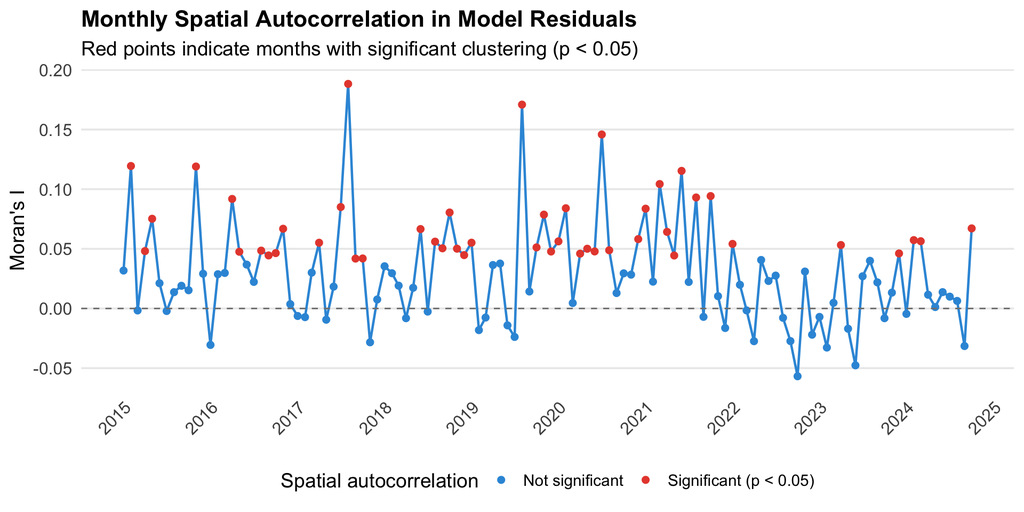

```r
# Compute monthly Moran's I
monthly_moran <- panel_best %>%
  mutate(year_month = format(date, "%Y-%m")) %>%
  group_by(year_month) %>%
  group_modify(~ {
    # Get district-level mean residuals for this month
    month_resid <- .x %>%
      group_by(admin2) %>%
      summarise(mean_resid = mean(resid, na.rm = TRUE), .groups = "drop") %>%
      left_join(district_covariates %>% select(admin2, lon, lat), by = "admin2") %>%
      filter(!is.na(lon), !is.na(lat), !is.na(mean_resid))

    # Need enough districts for k-nn
    if (nrow(month_resid) < k + 1) {
      return(data.frame(moran_i = NA, p_value = NA, n_districts = nrow(month_resid)))
    }

    # Compute Moran's I for this month
    coords_m <- as.matrix(month_resid[, c("lon", "lat")])
    knn_m <- knearneigh(coords_m, k = k)
    nb_m <- knn2nb(knn_m)
    listw_m <- nb2listw(nb_m, style = "W")

    moran_m <- tryCatch(
      moran.test(month_resid$mean_resid, listw_m),
      error = function(e) NULL
    )

    if (is.null(moran_m)) {
      return(data.frame(moran_i = NA, p_value = NA, n_districts = nrow(month_resid)))
    }

    data.frame(
      moran_i = moran_m$estimate["Moran I statistic"],
      p_value = moran_m$p.value,
      n_districts = nrow(month_resid)
    )
  }) %>%
  ungroup() %>%
  mutate(date = as.Date(paste0(year_month, "-01")))

# Plot monthly Moran's I
ggplot(monthly_moran %>% filter(!is.na(moran_i)), aes(x = date, y = moran_i)) +
  geom_line(color = "#3498db", linewidth = 0.8) +
  geom_point(aes(color = p_value < 0.05), size = 2) +
  geom_hline(yintercept = 0, linetype = "dashed", color = "gray50") +
  scale_color_manual(
    values = c("FALSE" = "#3498db", "TRUE" = "#e74c3c"),
    labels = c("Not significant", "Significant (p < 0.05)"),
    name = "Spatial autocorrelation"
  ) +
  scale_x_date(date_breaks = "1 year", date_labels = "%Y") +
  labs(
    x = NULL,
    y = "Moran's I",
    title = "Monthly Spatial Autocorrelation in Model Residuals",
    subtitle = "Red points indicate months with significant clustering (p < 0.05)"
  ) +
  theme_presentation +
  theme(axis.text.x = element_text(angle = 45, hjust = 1))
```

```r
# Summary
n_sig <- sum(monthly_moran$p_value < 0.05, na.rm = TRUE)
n_total <- sum(!is.na(monthly_moran$p_value))
cat(sprintf("\nMonthly summary: %d of %d months (%.1f%%) show significant spatial autocorrelation\n",
            n_sig, n_total, 100 * n_sig / n_total))
```

```
##
## Monthly summary: 47 of 118 months (39.8%) show significant spatial autocorrelation
```

# 8 Figures

## 8.1 Figure 1: Temporal Distribution

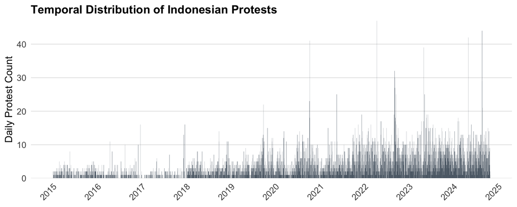

```r
daily_counts_plot <- protests_daily %>%
  group_by(date) %>%
  summarise(n = n(), .groups = "drop")

ggplot(daily_counts_plot, aes(x = date, y = n)) +
  geom_col(fill = "#2c3e50", alpha = 0.7, width = 1) +
  scale_x_date(date_breaks = "1 year", date_labels = "%Y") +
  scale_y_continuous(expand = c(0, 0), limits = c(0, NA)) +
  labs(x = NULL, y = "Daily Protest Count",
       title = "Temporal Distribution of Indonesian Protests") +
  theme_presentation +
  theme(axis.text.x = element_text(angle = 45, hjust = 1))
```

## 8.2 Figure 2: 2D Profile Likelihood (θ vs κ)

[figure not shown]

```r
# Prepare data for 2D heatmap
profile_2d <- results_2d %>%
  mutate(
    theta_label = ifelse(is.infinite(theta), "∞", as.character(theta)),
    theta_label = factor(theta_label,
                         levels = c("50", "100", "200", "300", "500", "750", "1000", "1500", "∞")),
    kappa_label = sprintf("%.2f", kappa),
    kappa_label = factor(kappa_label, levels = sprintf("%.2f", sort(unique(kappa)))),
    is_optimal = (theta == theta_hat & kappa == kappa_hat)
  )

# Find optimal point
opt_point <- profile_2d %>% filter(is_optimal)

ggplot(profile_2d, aes(x = theta_label, y = kappa_label, fill = deviance)) +
  geom_tile(color = "white", linewidth = 0.5) +
  geom_point(data = opt_point, aes(x = theta_label, y = kappa_label),
             color = "#e74c3c", size = 6, shape = 4, stroke = 2) +
  scale_fill_viridis_c(option = "plasma", direction = -1,
                       name = "Deviance") +
  labs(
    x = expression(paste("Spatial Decay ", theta, " (km)")),
    y = expression(paste("Temporal Decay ", kappa)),
    title = "2D Profile Likelihood: Spatial vs Temporal Decay",
    subtitle = sprintf("Optimal: θ = %s, κ = %.2f (marked with ×)",
                       ifelse(is.infinite(theta_hat), "∞", theta_hat), kappa_hat)
  ) +
  theme_presentation +
  theme(
    axis.text.x = element_text(angle = 45, hjust = 1),
    legend.position = "right"
  )
```

## 8.3 Figure 3: Temporal Decay Kernel

[figure not shown]

```r
# Plot the normalized temporal decay function g(l) = kappa^l / sum(kappa^m)
lags <- 1:30
w_opt <- kappa_hat^lags
w_opt <- w_opt / sum(w_opt)
w_unif <- rep(1/length(lags), length(lags))

kernel_data <- data.frame(
  lag = lags,
  weight_optimal = w_opt,
  weight_uniform = w_unif
)

# Compute half-life position
if (kappa_hat < 1) {
  hl_lag <- half_life
} else {
  hl_lag <- NA
}

# Find the weight at half-life for annotation placement
hl_weight <- if (!is.na(hl_lag) && hl_lag <= 30) w_opt[round(hl_lag)] else NA

ggplot(kernel_data, aes(x = lag)) +
  geom_line(aes(y = weight_uniform), color = "#95a5a6", linewidth = 1,
            linetype = "dashed") +
  geom_line(aes(y = weight_optimal), color = "#e74c3c", linewidth = 1.5) +
  geom_point(aes(y = weight_optimal), color = "#e74c3c", size = 2) +
  {if (!is.na(hl_lag) && hl_lag <= 30)
    geom_vline(xintercept = hl_lag, color = "#3498db", linetype = "dotted", linewidth = 1)} +
  {if (!is.na(hl_lag) && hl_lag <= 30)
    annotate("text", x = hl_lag + 1, y = max(w_opt) * 0.6,
             label = sprintf("Half-life\n%.1f days", half_life),
             hjust = 0, size = 4, color = "#3498db")} +
  annotate("text", x = 25, y = max(w_unif) + 0.005, label = "Uniform",
           color = "#95a5a6", size = 4) +
  annotate("text", x = 8, y = w_opt[5] + 0.01,
           label = sprintf("Normalized geometric (κ = %.2f)", kappa_hat),
           color = "#e74c3c", size = 4) +
  scale_x_continuous(breaks = c(1, 7, 14, 21, 30),
                     labels = c("1", "7", "14", "21", "30")) +
  scale_y_continuous(expand = c(0.02, 0)) +
  labs(
    x = "Lag (days)",
    y = "Temporal Weight g(ℓ)",
    title = "Normalized Temporal Decay Kernel",
    subtitle = sprintf("g(ℓ) = κ^ℓ / Σκ^m, κ = %.2f, half-life = %.1f days (weights sum to 1)", kappa_hat, half_life)
  ) +
  theme_presentation
```

## 8.4 Figure 4: Lag Structure

[figure not shown]

```r
lag_data <- data.frame(
  week = factor(c("Week 1\n(1-7)", "Week 2\n(8-14)", "Week 3\n(15-21)", "Week 4\n(22-30)"),
                levels = c("Week 1\n(1-7)", "Week 2\n(8-14)", "Week 3\n(15-21)", "Week 4\n(22-30)")),
  coef = lag_coefs[, 1],
  se = lag_coefs[, 2]
)

ggplot(lag_data, aes(x = week, y = coef)) +
  geom_col(fill = "#3498db", alpha = 0.8, width = 0.7) +
  geom_errorbar(aes(ymin = coef - 1.96*se, ymax = coef + 1.96*se),
                width = 0.25, linewidth = 0.8) +
  geom_hline(yintercept = 0, linetype = "dashed", color = "gray50") +
  labs(
    x = "Lag Period",
    y = "Coefficient",
    title = "Cross-District Contagion Effect by Temporal Lag"
  ) +
  theme_presentation
```

## 8.5 Figure 5: Covariate Effects

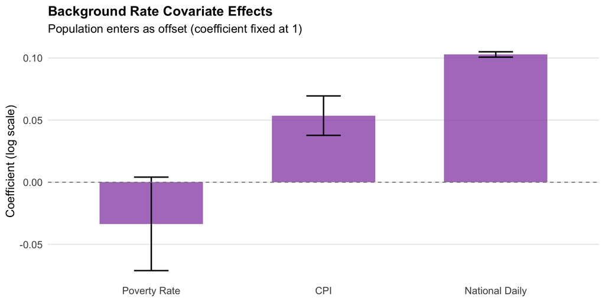

```r
coefs_plot <- coef(m1_best)
ses_plot <- summary(m1_best)$p.table[, "Std. Error"]

cov_df <- data.frame(
  variable = factor(c("Poverty Rate", "CPI", "National Daily"),
                    levels = c("Poverty Rate", "CPI", "National Daily")),
  estimate = c(coefs_plot["poverty_rate"], coefs_plot["cpi"], coefs_plot["national_daily"]),
  se = c(ses_plot["poverty_rate"], ses_plot["cpi"], ses_plot["national_daily"])
)

ggplot(cov_df, aes(x = variable, y = estimate)) +
  geom_col(fill = "#9b59b6", alpha = 0.8, width = 0.6) +
  geom_errorbar(aes(ymin = estimate - 1.96*se, ymax = estimate + 1.96*se),
                width = 0.2, linewidth = 0.8) +
  geom_hline(yintercept = 0, linetype = "dashed", color = "gray50") +
  labs(x = NULL, y = "Coefficient (log scale)",
       title = "Background Rate Covariate Effects",
       subtitle = "Population enters as offset (coefficient fixed at 1)") +
  theme_presentation
```

## 8.6 Figure 6: Spatial Kernel

[figure not shown]

```r
theta_plot <- ifelse(is.infinite(theta_hat), 100, theta_hat)

distances <- seq(0, 500, by = 5)
kernel_df <- data.frame(
  distance = distances,
  weight = exp(-distances / theta_plot),
  weight_uniform = rep(1, length(distances))
)

ggplot(kernel_df, aes(x = distance)) +
  geom_line(aes(y = weight), color = "#e74c3c", linewidth = 1.5) +
  geom_line(aes(y = weight_uniform), color = "#95a5a6", linewidth = 1, linetype = "dashed") +
  geom_vline(xintercept = theta_plot, color = "#e74c3c", linetype = "dotted") +
  annotate("text", x = theta_plot + 10, y = 0.5,
           label = paste0("θ = ", theta_plot, " km"),
           hjust = 0, size = 4, color = "#e74c3c") +
  annotate("text", x = 400, y = 0.95, label = "Uniform (no decay)",
           color = "#95a5a6", size = 4) +
  annotate("text", x = 300, y = 0.15, label = "Exponential decay",
           color = "#e74c3c", size = 4) +
  labs(
    x = "Distance (km)",
    y = "Weight",
    title = "Spatial Kernel: Exponential Decay vs. Uniform"
  ) +
  scale_y_continuous(limits = c(0, 1.1), expand = c(0, 0)) +
  theme_presentation
```